# STEVE ARCHULETA -- 22 DECEMBER 2024

### **INTELLIGENT REPORTING VIA MICROSOFT AZURE THROUGH A PIPELINE OF SCRIPTING JOBS**

#### DEPLOY A STREAMLIT DASHBOARD TO HUGGING FACE SPACES

#### PIZZA SALES ANALYSIS PROJECT

## **Problem Statement**

### **Business Context**

A moderately sized, locally popular food joint operates a chain of outlets located in a metropolitan area, offering a diverse menu of pizzas, sides, and beverages. Despite having a steady flow of customers, they face challenges in optimizing their order fulfillment process, leading to delays during peak hours, which results in customer dissatisfaction and impacts repeat business. Additionally, they struggle with inventory management, often experiencing shortages of popular ingredients or excess stock of less favored items. To address these issues, they are implementing a new order management system and seeking to analyze sales data to better predict demand and streamline inventory.

### **Objective**

The business has engaged Steve Archuleta as a Data Analyst to enhance operational efficiency and boost customer satisfaction. Steve has been provided raw historical sales data and has been tasked with pre-processing historical sales data to uncover trends, building an interactive dashboard to enable visual reporting of key metrics, and generating email reports to communicate key insights to stakeholders. This analysis will enable the stakeholders to get a clearer understanding of the business, stay on top of changing market scenarios via frequent alerts, and make quick, informed decisions to resolve operational challenges. The anticipated outcomes include reduced order processing times, improved inventory turnover, and increased customer satisfaction leading to higher repeat sales.

### **Data Description:**

This dataset contain detailed information about pizza orders, including specifics about the pizza variants, quantities, pricing, dates, times, and categorization details.

- **pizza_id:** A unique identifier assigned to each distinct pizza variant available for ordering.
- **order_id:** A unique identifier for each order made, which links to multiple pizzas.
- **pizza_name_id:** An identifier linking to a specific name of the pizza.
- **quantity:** The number of units of a specific pizza variant ordered within an order.
- **order_date:** The date when the order was placed.
- **order_time:** The time when the order was placed.
- **unit_price:** The cost of a single unit of the specific pizza variant.
- **pizza_size:** Represents the size of the pizza (e.g., small, medium, large).
- **pizza_category:** Indicates the category of the pizza, such as vegetarian, non-vegetarian, etc.
- **pizza_name:** Specifies the name of the specific pizza variant ordered.

### **STEVE ARCHULETA'S PERSONAL NOTES:**

-- **LIST OF JOBS**

```
- #A. Preprocessing Step (Pipeline Step)
- #B. Hugging Face Step (Pipeline Step)
- #C. Email Reporting Step (Pipeline Step)
- #D. Pipeline Assembly Step (Submit the entire Pipeline to MLClient)
```

-- **LIST OF DIRECTORY PATHS**

```
- src_dir_env = "./project_env"
- src_dir_job_scripts = "./project_scripts"
- src_dir_hf_space = "./files"
```

-- **LIST OF FILE SCRIPT PATHS**

```
- local_data_path = '/pizza_sales.csv’
- conda_file = "./project_env/conda.yml"
- src_dir_job_scripts/pre_process.py
-
```

-- **LIST OF FUNCTIONS**

[output not shown]

-- **LIST OF COMMAND FUNCTION CONFIGURATION STEPS**

```
- step_process_pre_process = command(...)
-
```

```python
# INSTALL THE SEABORN LIBRARY
%pip install seaborn
```

```python
# ==============================================
# IMPORT LIBRARIES THAT ARE USED IN THIS PROJECT
# ==============================================
import git
from azure.ai.ml import MLClient
from azure.identity import DefaultAzureCredential
from azure.ai.ml.entities import AmlCompute
from azure.ai.ml import Input, Output, command
from azure.ai.ml.entities import Environment
from azure.ai.ml import dsl
import os
from azure.ai.ml.entities import Data
from azure.ai.ml.constants import AssetTypes
import pandas as pd
import numpy as np
import matplotlib.pyplot as plt
from matplotlib.lines import Line2D
import seaborn as sns
import argparse
from pathlib import Path
import smtplib
from email.mime.multipart import MIMEMultipart
from email.mime.text import MIMEText
import warnings
warnings.filterwarnings("ignore", category=FutureWarning)  # Suppress future warnings
```

### Git and Project Initialization (Bash Commands)

```python
# # ================================
# # GIT SAFE DIRECTORY CONFIGURATION
# # ================================
# !git config user.email "stevearchuleta@me.com"
# !git config user.name "Steve Archuleta"

# git config --global --add safe.directory "C:/Users/steve/Documents/01_ACADEMIA/GREAT_LEARNING/MICROSOFT_AI_PROFESSIONAL_PROGRAM_AI_to_OPEN_AI/PROJECT_01_DATA_FOUNDATIONS_ON_AZURE_PIZZA_SALES_ANALYSIS/Pizza_Sales_Analysis_Full_Code.ipynb"

# # =============================================================
# # ECHO A HEADER INTO THE README.MD FILE TO DESCRIBE THE PROJECT
# # =============================================================
# echo "# Intelligent_Reporting_on_AzureML_Pipeline_Pizza_Sales_Dashboard" >> README.md

# # =====================
# # INITIALIZE A GIT REPO
# # =====================
# git init

# # =====================
# # STAGE THE README FILE
# # =====================
# git add README.md

# # ==========================
# # COMMIT THE INITIAL CHANGES
# # ==========================
# git commit -m "first commit"

# # ===================================
# # CREATE THE MAIN BRANCH FOR GIT REPO
# # ===================================
# git branch -M main

# # =============================================
# # LINK THE LOCAL REPO TO THE REMOTE GITHUB REPO
# # =============================================
# git remote add origin https://github.com/stevearchuleta/Intelligent_Reporting_on_Azure_ML_Pipeline_Pizza_Sales_Dashboard.git

# # ==========================================
# # PUSH THE INITIAL COMMIT TO THE MAIN BRANCH
# # ==========================================
# git push -u origin main
```

## **AzureML Setup and Data Loading**

### **Create Compute Cluster** -- AzureML Compute Setup

### **Connect to Azure Machine Learning Workspace**

```python
# ========================================================================
# IMPORT THE REQUIRED AZURE ML MODULES TO MANAGE THE WORKSPACE AND COMPUTE
# ========================================================================
# from azure.ai.ml import MLClient
# from azure.identity import DefaultAzureCredential
# from azure.ai.ml.entities import AmlCompute

# =====================================================
# CREATE A DEFAULT CREDENTIAL OBJECT FOR AUTHENTICATION
# =====================================================
credential = DefaultAzureCredential()

# ==============================================================
# CREATE A MLCLIENT INSTANCE TO COMMUNICATE WITH AZURE WORKSPACE
# ==============================================================
ml_client = MLClient(
    credential=credential,
    subscription_id="af6e7bea-cbc6-4f83-ab20-3169af7fccdf",
    resource_group_name="default_resource_group",
    workspace_name="pizza-sales-intelligent-reporting"
)

# ==================================
# DEFINE THE NAME OF THE CPU CLUSTER
# ==================================
cpu_compute_target = "cpu-cluster"

# =======================================================
# CHECK IF THE CLUSTER ALREADY EXISTS OR CREATE A NEW ONE
# =======================================================
try:
    # ==== TRY TO GET EXISTING CLUSTER
    cpu_cluster = ml_client.compute.get(cpu_compute_target)
    print(f"ALREADY USING EXISTING CLUSTER NAMED {cpu_compute_target}.")
except Exception:
    print("CREATING A NEW CPU COMPUTE TARGET...")
    # ==== CREATE A NEW CPU CLUSTER WITH DEFINED PARAMETERS
    cpu_cluster = AmlCompute(
        name=cpu_compute_target,
        type="amlcompute",
        size="Standard_A2_v2",
        min_instances=0,
        max_instances=1,
        idle_time_before_scale_down=180,
        tier="Dedicated"
    )
    # ==== CREATE OR UPDATE THE CLUSTER IN AZURE ML WORKSPACE
    cpu_cluster = ml_client.compute.begin_create_or_update(cpu_cluster).result()
    print(f"COMPUTE CLUSTER {cpu_cluster.name} CREATED WITH SIZE {cpu_cluster.size}.")
```

```
ALREADY USING EXISTING CLUSTER NAMED cpu-cluster.
```

👆 OBSERVATION

### **Register Dataset as a Data Asset in AzureML** -- A BLOB Storage

```python
import os
print(os.getcwd())
```

```
/mnt/batch/tasks/shared/LS_root/mounts/clusters/dec222024/code/Users/Steven_1729279359702
```

```python
# =======================
# IMPORT REQUIRED MODULES
# =======================
# from azure.ai.ml.entities import Data
# from azure.ai.ml.constants import AssetTypes

# ======================
# DEFINE LOCAL DATA PATH
# ======================
local_data_path = 'pizza_sales.csv'

# ==============================
# CREATE A DATA ASSET DEFINITION
# ==============================
data_asset = Data(
    path=local_data_path,
    type=AssetTypes.URI_FILE,
    description="A DATASET OF PIZZA SALES",
    name="pizza-analysis-data"
)

# =============================================================
# REGISTER THE DATA ASSET WITH THE ML CLIENT (CREATE OR UPDATE)
# =============================================================
ml_client.data.create_or_update(data_asset)
```

```
Data({'path': 'azureml://subscriptions/af6e7bea-cbc6-4f83-ab20-3169af7fccdf/resourcegroups/default_resource_group/workspaces/pizza-sales-intelligent-reporting/datastores/workspaceblobstore/paths/LocalUpload/c1e3841d1aef92e0b27bbe4cf1e978e7/pizza_sales.csv', 'skip_validation': False, 'mltable_schema_…
```

👆 OBSERVATION

- PIZZA SALES DATASET SUCCESSFULLY UPLOADED AND REGISTERED AS A DATA ASSET.
- DATA ASSET NAME: pizza-analysis-data
- DATA TYPE: uri_file
- VERSION: 1

### **Create a Job Environment with Conda YAML**

```python
# =========================================================
# CREATE A DIRECTORY FOR STORING THE CONDA ENVIRONMENT FILE
# =========================================================
src_dir_env = "./project_env"
os.makedirs(src_dir_env, exist_ok=True)

# ==========================================================
# WRITE THE CONDA.YML FILE WITH DEPENDENCIES FOR THE PROJECT
# ==========================================================
conda_yaml_content = """name: sklearn-env
channels:
  - conda-forge
dependencies:
  - python=3.8
  - pip=21.2.4
  - scikit-learn=0.23.2
  - scipy=1.7.1
  - pip:
    - mlflow==2.8.1
    - azureml-mlflow==1.51.0
    - azureml-inference-server-http
    - azureml-core==1.57.0
    - cloudpickle==1.6.0
    - huggingface_hub
    - datasets
    - seaborn
    - pandas
"""

with open(os.path.join(src_dir_env, "conda.yml"), "w") as f:
    f.write(conda_yaml_content)

# =======================================================
# CREATE AN ENVIRONMENT OBJECT USING THE ABOVE CONDA YAML
# =======================================================
from azure.ai.ml.entities import Environment, BuildContext
env_docker_conda = Environment(
    image="mcr.microsoft.com/azureml/openmpi4.1.0-ubuntu20.04",
    conda_file="./project_env/conda.yml",
    name="intelligent-reporting-azure",
    description="ENVIRONMENT WITH CONDA DEPENDENCIES FOR PIZZA SALES ANALYSIS"
)

# =======================================
# CREATE OR UPDATE THE ENVIRONMENT IN AML
# =======================================
ml_client.environments.create_or_update(env_docker_conda)
```

```
Environment({'arm_type': 'environment_version', 'latest_version': None, 'image': 'mcr.microsoft.com/azureml/openmpi4.1.0-ubuntu20.04', 'intellectual_property': None, 'is_anonymous': False, 'auto_increment_version': False, 'auto_delete_setting': None, 'name': 'intelligent-reporting-azure', 'descripti…
```

👆 OBSERVATION

- NEW ENVIRONMENT SUCCESSFULLY CREATED/UPDATED.  
  ENVIRONMENT NAME: intelligent-reporting-azure  
  ENVIRONMENT VERSION: 1  
  DESCRIPTION: ENVIRONMENT WITH CONDA DEPENDENCIES FOR PIZZA SALES ANALYSIS
- A .yml FILE, OFTEN CALLED A YAML FILE, IS A CONFIGURATION FILE LISTING SOFTWARE DEPENDENCIES IN A STRUCTURED, HUMAN-READABLE FORMAT. IN THE GIVEN PIPELINE, THE conda.yml FILE SPECIFIES PYTHON VERSION AND PACKAGES NEEDED, ENSURING A CONSISTENT ENVIRONMENT FOR RUNNING CODE AND AVOIDING DEPENDENCY CONFLICTS.
- A DOCKER IMAGE FILE IS A PACKAGED SNAPSHOT OF AN ENVIRONMENT, INCLUDING THE OPERATING SYSTEM, LIBRARIES, AND TOOLS. USING A PREDEFINED DOCKER IMAGE (LIKE A BASE IMAGE FROM mcr.microsoft.com/azureml) CREATES A CONSISTENT, PORTABLE ENVIRONMENT CAPABLE OF RUNNING THE PIPELINE SEAMLESSLY ACROSS DIFFERENT SYSTEMS, ENSURING REPRODUCIBILITY AND RELIABILITY.
- CREATING AND REGISTERING THE DOCKER IMAGE FILE ENVIRONMENT WITH AZURE ML GRANTS THE MACHINE LEARNING PIPELINE A STABLE RUNTIME, ALLOWING CODE, DATA, AND DEPENDENCIES TO REMAIN CONSISTENT. THE CONFIGURED ENVIRONMENT FUNCTIONS LIKE A CONTROLLED LABORATORY SETUP, ENSURING COMPUTATIONS YIELD IDENTICAL RESULTS REGARDLESS OF LOCATION OR TIME OF EXECUTION.
- EXECUTION OF ENVIRONMENT CREATION STEPS IS ESSENTIAL FOR A MACHINE LEARNING WORKFLOW: THE SPECIFIED CONFIGURATION DEFINES ALL REQUIRED PACKAGES, PYTHON LIBRARIES, AND EXTERNAL DEPENDENCIES IN ONE PLACE. THEREFORE, SUBSEQUENT PIPELINE STEPS—SUCH AS DATA PREPROCESSING, MODEL TRAINING, OR INFERENCE—OCCUR IN A CAREFULLY MANAGED AND PREDICTABLE ENVIRONMENT.

## Exploratory Data Analysis

### **Data Overview**

```python
# import pandas as pd
# import numpy as np
# import matplotlib.pyplot as plt
# import seaborn as sns

# =============================================
# RESTRICT THE FLOAT VALUES TO 2 DECIMAL PLACES
# =============================================
pd.set_option('display.float_format', lambda x: '%.2f' % x)
pd.set_option("display.max_columns", None)  # DISPLAY ALL COLUMNS
pd.set_option("display.max_rows", 200)  # DISPLAY 200 ROWS
```

```python
data = pd.read_csv('pizza_sales.csv')
```

```python
# =============================
# INFORMATION ABOUT THE DATASET
# =============================
data.info()
```

```
<class 'pandas.core.frame.DataFrame'>
RangeIndex: 48620 entries, 0 to 48619
Data columns (total 12 columns):
 #   Column             Non-Null Count  Dtype
---  ------             --------------  -----
 0   pizza_id           48620 non-null  float64
 1   order_id           48620 non-null  float64
 2   pizza_name_id      48620 non-null  object
 3   quantity           48620 non-null  float64
 4   order_date         48620 non-null  object
 5   order_time         48620 non-null  object
 6   unit_price         48620 non-null  float64
 7   total_price        48620 non-null  float64
 8   pizza_size         48620 non-null  object
 9   pizza_category     48620 non-null  object
 10  pizza_ingredients  48620 non-null  object
 11  pizza_name         48620 non-null  object
dtypes: float64(5), object(7)
memory usage: 4.5+ MB
```

👆 OBSERVATION

- TOTAL ROWS: 48,620; COLUMNS: 12; INDEX RANGE: 0 TO 48,619.
- COLUMNS WITH FLOAT64: pizza_id, order_id, quantity, unit_price, total_price. NOTE: convert order_id and pizza_id to object.
- COLUMNS WITH OBJECT DTYPE: pizza_name_id, order_date, order_time, pizza_size, pizza_category, pizza_ingredients, pizza_name. NOTE: convert order_data and order_time to datetime.
- NO NULL VALUES DETECTED IN ANY COLUMN; FULLY POPULATED DATASET.
- MEMORY USAGE: APPROXIMATELY 4.5 MB; DATASET IS RELATIVELY MANAGEABLE IN SIZE.

```python
# ============================
# LOAD THE PIZZA SALES DATASET
# ============================
# data = pd.read_csv('pizza_sales.csv')

# ================
# SHAPE OF DATASET
# ================
print(data.shape)
print('\n')

# ======================================
# DISPLAY THE FIRST FIVE ROWS OF DATASET
# ======================================
data.head()
```

```
(48620, 12)
```

|  | pizza_id | order_id | pizza_name_id | quantity | order_date | order_time | unit_price | total_price | pizza_size | pizza_category | pizza_ingredients | pizza_name |
| --- | --- | --- | --- | --- | --- | --- | --- | --- | --- | --- | --- | --- |
| 0 | 1.00 | 1.00 | hawaiian_m | 1.00 | 1/1/2015 | 11:38:36 | 13.25 | 13.25 | M | Classic | Sliced Ham, Pineapple, Mozzarella Cheese | The Hawaiian Pizza |
| 1 | 2.00 | 2.00 | classic_dlx_m | 1.00 | 1/1/2015 | 11:57:40 | 16.00 | 16.00 | M | Classic | Pepperoni, Mushrooms, Red Onions, Red Peppers,... | The Classic Deluxe Pizza |
| 2 | 3.00 | 2.00 | five_cheese_l | 1.00 | 1/1/2015 | 11:57:40 | 18.50 | 18.50 | L | Veggie | Mozzarella Cheese, Provolone Cheese, Smoked Go... | The Five Cheese Pizza |
| 3 | 4.00 | 2.00 | ital_supr_l | 1.00 | 1/1/2015 | 11:57:40 | 20.75 | 20.75 | L | Supreme | Calabrese Salami, Capocollo, Tomatoes, Red Oni... | The Italian Supreme Pizza |
| 4 | 5.00 | 2.00 | mexicana_m | 1.00 | 1/1/2015 | 11:57:40 | 16.00 | 16.00 | M | Veggie | Tomatoes, Red Peppers, Jalapeno Peppers, Red O... | The Mexicana Pizza |

👆 OBSERVATION

- DATASET SHAPE: 48,620 rows/records, 12 columns/features
- DATASET DISPLAYS FIRST 5 ROWS (INDEX 0 THROUGH 4).
- FEATURE NAMES IDENTIFIED: pizza_id, order_id, pizza_name_id, quantity, order_date, order_time, unit_price, total_price, pizza_size, pizza_category, pizza_ingredients, pizza_name.
- MULTIPLE DATA TYPES PRESENT: DATE/TIME COLUMNS (order_date, order_time), NUMERIC COLUMNS (pizza_id, order_id, quantity, unit_price, total_price) AND CATEGORICAL/TEXT COLUMNS (pizza_name_id, pizza_size, pizza_category, pizza_ingredients, pizza_name).
- A VARIETY OF PIZZA TYPES AND INGREDIENTS ARE SHOWN IN THE PREVIEW.

```python
# ====================================================================
# CONVERTING DATA TYPES FOR pizza_id, order_id, order_date, order_time
# ====================================================================

# ==== THESE COLUMNS ARE IDENTIFIERS AND NOT USED FOR MATHEMATICAL OPERATIONS ====
data['pizza_id'] = data['pizza_id'].astype(str)
data['order_id'] = data['order_id'].astype(str)

# ==== BENEFICIAL FOR TIME-BASED ANALYSIS AND FEATURE EXTRACTION ====
data['order_date'] = pd.to_datetime(data['order_date'])
data['order_time'] = pd.to_datetime(data['order_time'])

data.info()
```

```
<class 'pandas.core.frame.DataFrame'>
RangeIndex: 48620 entries, 0 to 48619
Data columns (total 12 columns):
 #   Column             Non-Null Count  Dtype
---  ------             --------------  -----
 0   pizza_id           48620 non-null  object
 1   order_id           48620 non-null  object
 2   pizza_name_id      48620 non-null  object
 3   quantity           48620 non-null  float64
 4   order_date         48620 non-null  datetime64[ns]
 5   order_time         48620 non-null  datetime64[ns]
 6   unit_price         48620 non-null  float64
 7   total_price        48620 non-null  float64
 8   pizza_size         48620 non-null  object
 9   pizza_category     48620 non-null  object
 10  pizza_ingredients  48620 non-null  object
 11  pizza_name         48620 non-null  object
dtypes: datetime64[ns](2), float64(3), object(7)
memory usage: 4.5+ MB
```

```python
# =======================================
# DESCRIBE NUMERIC COLUMNS IN THE DATASET
# =======================================
print("SUMMARY STATISTICS FOR NUMERIC COLUMNS:")
numeric_cols = data.select_dtypes(include=[np.number])
numeric_cols.describe().T
```

```
SUMMARY STATISTICS FOR NUMERIC COLUMNS:
```

|  | count | mean | std | min | 25% | 50% | 75% | max |
| --- | --- | --- | --- | --- | --- | --- | --- | --- |
| quantity | 48620.00 | 1.02 | 0.14 | 1.00 | 1.00 | 1.00 | 1.00 | 4.00 |
| unit_price | 48620.00 | 16.49 | 3.62 | 9.75 | 12.75 | 16.50 | 20.25 | 35.95 |
| total_price | 48620.00 | 16.82 | 4.44 | 9.75 | 12.75 | 16.50 | 20.50 | 83.00 |

👆 OBSERVATION

- THREE NUMERIC FEATURES (quantity, unit_price, total_price) ARE ANALYZED.
- quantity HAS A MEAN OF APPROXIMATELY 1.02 AND RARELY EXCEEDS 1, INDICATING MOST ORDERS INCLUDE A SINGLE UNIT.
- unit_price HAS A MEAN OF ~16.49 WITH A RANGE FROM 9.75 TO 35.95, SUGGESTING A MODERATELY BROAD PRICE DISTRIBUTION.
- total_price HAS A MEAN OF ~16.82, SIMILAR TO unit_price, BUT MAXES AT 83.00, INDICATING OCCASIONAL HIGH-VALUE ORDERS.

```python
# ====================================================
# DESCRIBE CATEGORICAL (OBJECT) COLUMNS IN THE DATASET
# ====================================================

categorical_cols = data.select_dtypes(include=['object'])
print("SUMMARY STATISTICS FOR CATEGORICAL COLUMNS:")
categorical_cols.describe().T
```

```
SUMMARY STATISTICS FOR CATEGORICAL COLUMNS:
```

|  | count | unique | top | freq |
| --- | --- | --- | --- | --- |
| pizza_id | 48620 | 48620 | 1.0 | 1 |
| order_id | 48620 | 21350 | 18845.0 | 21 |
| pizza_name_id | 48620 | 91 | big_meat_s | 1811 |
| pizza_size | 48620 | 5 | L | 18526 |
| pizza_category | 48620 | 4 | Classic | 14579 |
| pizza_ingredients | 48620 | 32 | Pepperoni, Mushrooms, Red Onions, Red Peppers,... | 2416 |
| pizza_name | 48620 | 32 | The Classic Deluxe Pizza | 2416 |

👆 OBSERVATION

- MULTIPLE CATEGORICAL FEATURES WITH VARYING LEVELS OF UNIQUENESS ARE PRESENT.
- pizza_id HAS 48,620 UNIQUE VALUES, INDICATING THAT IT IS LIKELY AN IDENTIFIER RATHER THAN A CATEGORICAL FEATURE.
- order_id HAS 21,350 UNIQUE VALUES, TOP ONE APPEARING 21 TIMES, SUGGESTING ORDER_ID IS ALSO IDENTIFICATION-RELATED.
- pizza_name_id HAS 91 UNIQUE VALUES, TOP (big_meat_s) APPEARING 1,811 TIMES, INDICATING SOME PIZZAS ARE MUCH MORE POPULAR.
- pizza_size HAS ONLY 5 CATEGORIES, L (Large) is the most frequently ordered pizza_size.
- pizza_category HAS 4 CATEGORIES, Classic is the most frequently ordered pizza_category.
- pizza_ingredients AND pizza_name EACH HAVE 32 UNIQUE COMBINATIONS/VARIANTS, WITH A CLEAR TOP OPTION FREQUENTLY ORDERED.

```python
# ======================================
# VALUE COUNTS OF NON-NUMERIC FEATURES
# A MORE DETAILED FREQUENCY DISTRIBUTION
# ======================================
NUM_TO_DISPLAY = 10
for colname in data.select_dtypes(include=['object']).columns:
    val_counts = data[colname].value_counts(dropna=False)
    print(f"VALUE COUNTS FOR: {colname}")
    print(val_counts[:NUM_TO_DISPLAY])
    if len(val_counts) > NUM_TO_DISPLAY:
        print(f"Displaying first {NUM_TO_DISPLAY} of {len(val_counts)} unique categories.")
    print('\n')
```

```
VALUE COUNTS FOR: pizza_id
1.0        1
32418.0    1
32409.0    1
32410.0    1
32411.0    1
32412.0    1
32413.0    1
32414.0    1
32415.0    1
32416.0    1
Name: pizza_id, dtype: int64
Displaying first 10 of 48620 unique categories.


VALUE COUNTS FOR: order_id
18845.0    21
10760.0    21
18280.0    15
21158.0    15
17464.0    15
20163.0    15
14304.0    15
13906.0    15
20710.0    15
9650.0     14
Name: order_id, dtype: int64
Displaying first 10 of 21350 unique categories.


VALUE COUNTS FOR: pizza_name_id
big_meat_s       1811
thai_ckn_l       1365
five_cheese_l    1359
four_cheese_l    1273
classic_dlx_m    1159
spicy_ital_l     1088
hawaiian_s       1001
southw_ckn_l      993
bbq_ckn_l         967
```

[output cut: 35 more lines]

```


VALUE COUNTS FOR: pizza_name
The Classic Deluxe Pizza        2416
The Barbecue Chicken Pizza      2372
The Hawaiian Pizza              2370
The Pepperoni Pizza             2369
The Thai Chicken Pizza          2315
The California Chicken Pizza    2302
The Sicilian Pizza              1887
The Spicy Italian Pizza         1887
The Southwest Chicken Pizza     1885
The Four Cheese Pizza           1850
Name: pizza_name, dtype: int64
Displaying first 10 of 32 unique categories.
```

👆 OBSERVATION

- MULTIPLE NON-NUMERIC COLUMNS DISPLAY HIGH CARDINALITY; pizza_id HAS 48,620 UNIQUE VALUES, order_id HAS 21,350 UNIQUE VALUES.
- TOP FREQUENCIES VARY; pizza_id's TOP 10 HAVE A COUNT OF 1 EACH, WHILE order_id SHOWS UP TO 21 OCCURRENCES FOR THE MOST FREQUENT VALUE, SUGGESTING THAT order_id CAN BE ASSOCIATED WITH MULTIPLE ROWS/PIZZAS IN THE DATA, MEANING THAT THERE IS AT LEAST ONE ORDER THAT INCLUDES 21 ITEMS. AN ORDER CAN CONSIST OF MULTIPLE PIZZAS, AND EACH PIZZA LINE ITEM IS REPRESENTED AS A SEPARATE ROW IN THE DATASET.
- pizza_name_id HAS 91 UNIQUE CATEGORIES WITH 'big_meat_s' BEING THE MOST FREQUENT (1811 OCCURRENCES).
- pizza_size HAS ONLY 5 CATEGORIES, WITH 'L' OCCURRING MOST FREQUENTLY (18,526 TIMES).
- pizza_category SHOWS 4 CATEGORIES, 'Classic' OCCURS MOST (14,579 TIMES).
- pizza_ingredients AND pizza_name EACH HAVE 32 UNIQUE CATEGORIES, WITH THE TOP ONE OCCURRING OVER 2,400 TIMES.

```python
# ==================================================
# DESCRIBE DATETIME COLUMNS (order_date, order_time)
# ==================================================

datetime_cols = data.select_dtypes(include=['datetime64[ns]'])
datetime_cols.describe()
```

|  | order_date | order_time |
| --- | --- | --- |
| count | 48620 | 48620 |
| unique | 358 | 16382 |
| top | 2015-11-26 00:00:00 | 2024-12-22 12:32:00 |
| freq | 261 | 26 |
| first | 2015-01-01 00:00:00 | 2024-12-22 09:52:21 |
| last | 2015-12-31 00:00:00 | 2024-12-22 23:05:52 |

👆 OBSERVATION

```python
# =====================================
# CALCULATING THE SUM OF DUPLICATE ROWS
# =====================================

duplicate_count = data.duplicated().sum()
print("Number of Duplicate Rows:", duplicate_count)
```

```
Number of Duplicate Rows: 0
```

👆 OBSERVATION

- NO DUPLICATE ROWS DETECTED; duplicate_count IS 0.

```python
# =============================================================================
# CALCULATING SUM OF MISSING VALUES AND CHECKING FOR MISSING VALUES PER FEATURE
# =============================================================================
print(data.isnull().sum())

print('\n')

print(data.isna().any())
```

```
pizza_id             0
order_id             0
pizza_name_id        0
quantity             0
order_date           0
order_time           0
unit_price           0
total_price          0
pizza_size           0
pizza_category       0
pizza_ingredients    0
pizza_name           0
dtype: int64


pizza_id             False
order_id             False
pizza_name_id        False
quantity             False
order_date           False
order_time           False
unit_price           False
total_price          False
pizza_size           False
pizza_category       False
pizza_ingredients    False
pizza_name           False
dtype: bool
```

👆 OBSERVATION

- NO MISSING VALUES IN ANY FEATURE; ALL COLUMNS HAVE 0 NULLS.
- BOOLEAN CHECK CONFIRMS NO COLUMN CONTAINS MISSING DATA (ALL FALSE).

```python
# ============================================================
# COPY THE DATA DATAFRAME INTO A NEW VARIABLE CALLED df
# USING THE .copy() METHOD CREATES A NEW INDEPENDENT DATAFRAME
# ============================================================
df = data.copy()
```

### **Univariate Analysis**

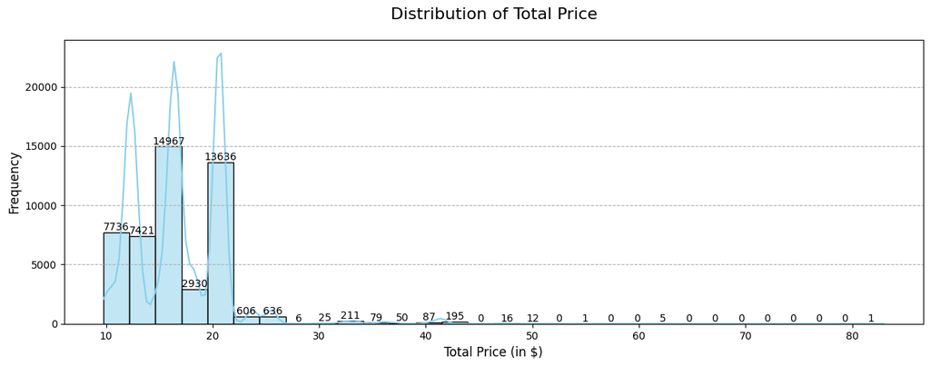

```python
# ============================================
# HISTOGRAM FOR total_price, A NUMERIC FEATURE
# THE DISTRIBUTION OF TOTAL PRICE (REFORMATTED)
# ============================================

plt.figure(figsize=(15, 5))
ax = sns.histplot(data=df, x='total_price', bins=30, kde=True, color="skyblue")

# ADD COUNTS ON TOP OF BARS
for p in ax.patches:
    ax.annotate(
        format(p.get_height(), '.0f'),  # Format count as integer
        (p.get_x() + p.get_width() / 2., p.get_height()),
        ha='center', va='center', fontsize=10, color='black', xytext=(0, 5), textcoords='offset points'
    )

# ADD TITLE AND LABELS
plt.title("Distribution of Total Price", fontsize=16, pad=20)
plt.xlabel("Total Price (in $)", fontsize=12)
plt.ylabel("Frequency", fontsize=12)
plt.grid(axis='y', linestyle='--')

# DISPLAY THE PLOT
plt.show()
```

👆 OBSERVATION

- DISTRIBUTION IS HEAVILY CONCENTRATED BETWEEN APPROX. $9.75 AND $22, WITH MULTIPLE PEAKS IN THAT RANGE.
- COUNTS ON TOP OF BARS SHOW HIGH FREQUENCY IN LOWER PRICE TIERS, INDICATING MOST ORDERS HAVE A TOTAL PRICE UNDER $20.
- HIGHER PRICE POINTS ABOVE $30 ARE RARE, WITH VERY FEW ORDERS EXCEEDING THAT THRESHOLD.
- THE KDE CURVE CONFIRMS A MULTI-MODAL DISTRIBUTION IN THE LOWER RANGE, SUGGESTING DISTINCT PRICE GROUPINGS.

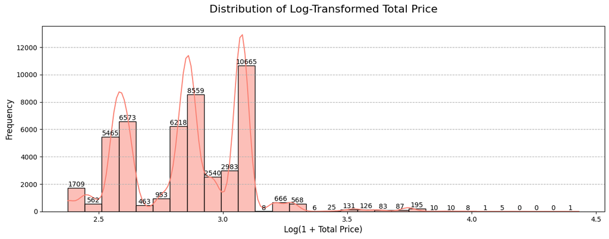

```python
# ===========================================================================
# HISTOGRAM FOR A LOG-TRANSFORMED total_price, A NUMERIC FEATURE
# IF TOTAL_PRICE IS SKEWED, APPLY LOG TRANSFORMATION TO IMPROVE VISUALIZATION
# ===========================================================================

log_total_price = np.log1p(df['total_price'])

# PLOT HISTOGRAM
plt.figure(figsize=(15, 5))
ax = sns.histplot(x=log_total_price, bins=30, kde=True, color='salmon')

# ADD COUNTS ON TOP OF BARS
for p in ax.patches:
    ax.annotate(
        format(p.get_height(), '.0f'),
        (p.get_x() + p.get_width() / 2., p.get_height()),
        ha='center', va='center', fontsize=10, color='black', xytext=(0, 5), textcoords='offset points'
    )

# ADD TITLE AND LABELS
plt.title("Distribution of Log-Transformed Total Price", fontsize=16, pad=20)
plt.xlabel("Log(1 + Total Price)", fontsize=12)
plt.ylabel("Frequency", fontsize=12)
plt.grid(axis='y', linestyle='--')

# DISPLAY THE PLOT
plt.show()
```

👆 OBSERVATION

- APPLYING A LOG TRANSFORMATION COMPRESSES THE DISTRIBUTION, MAKING PRICE DIFFERENCES MORE VISUALLY COMPARABLE.
- MULTIPLE PEAKS ARE STILL EVIDENT, SUGGESTING DISTINCT PRICE CLUSTERS REMAIN EVEN AFTER TRANSFORMATION.
- HIGH COUNTS IN THE LOWER LOG RANGE INDICATE THE MAJORITY OF ORDERS STILL CLUSTER AT LOWER PRICE LEVELS.
- EXTREMELY HIGH VALUES ARE RELATIVELY SCARCE, AS INDICATED BY FEW BARS AT THE UPPER END OF THE LOG SCALE.

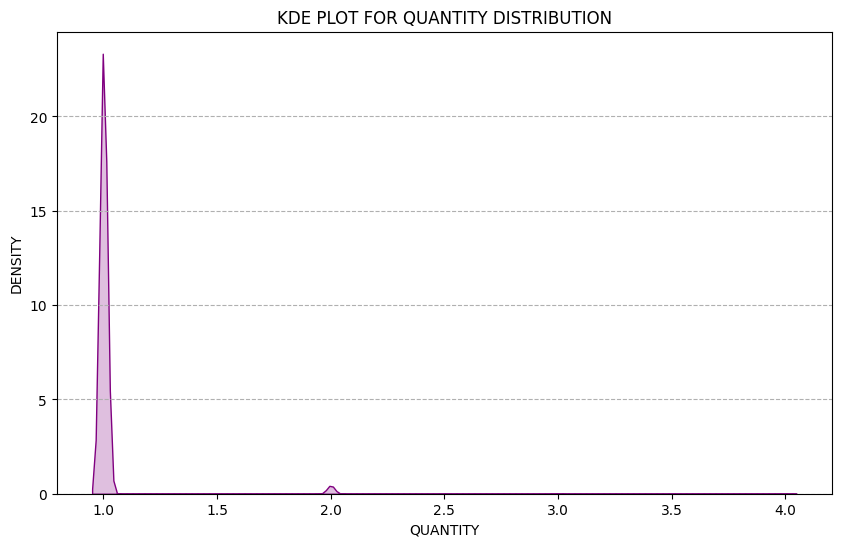

```python
# ========================================================
# KDE PLOT FOR quantity, A NUMERIC FEATURE
# THE KERNEL DENSITY ESTIMATE OF THE QUANTITY DISTRIBUTION
# ========================================================

plt.figure(figsize=(10, 6))
sns.kdeplot(df['quantity'], fill=True, color='purple')
plt.title("KDE PLOT FOR QUANTITY DISTRIBUTION")
plt.xlabel("QUANTITY")
plt.ylabel("DENSITY")
plt.grid(axis='y', linestyle='--')
plt.show()
```

👆 OBSERVATION

- THE KDE (KERNEL DENSITY ESTIMATE) PROVIDES A SMOOTHER REPRESENTATION OF DATA DISTRIBUTION COMPARED TO A HISTOGRAM, SHOWING PROBABILITY DENSITY INSTEAD OF BAR HEIGHTS.
- QUANTITY = 1 DOMINATES THE DISTRIBUTION, WITH AN EXTREMELY SHARP PEAK AT 1, INDICATING MOST ORDERS INCLUDE A SINGLE ITEM.
- ONLY A MINOR INDICATION OF QUANTITIES ABOVE 1, SUCH AS A SMALL BUMP AROUND 2, SUGGESTS FEW ORDERS WITH MORE THAN ONE ITEM.

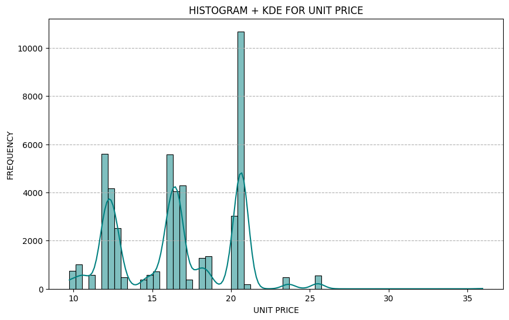

```python
# =============================================
# DIST PLOT FOR unit_price, A NUMERIC FEATURE
# COMBINES A HISTOGRAM AND A KDE PLOT
# =============================================

plt.figure(figsize=(10, 6))
sns.histplot(df['unit_price'], kde=True, color='teal')
plt.title("HISTOGRAM + KDE FOR UNIT PRICE")
plt.xlabel("UNIT PRICE")
plt.ylabel("FREQUENCY")
plt.grid(axis='y', linestyle='--')
plt.show()
```

👆 OBSERVATION

- THE DISTRIBUTION APPEARS MULTI-MODAL, WITH MULTIPLE PEAKS CLUSTERED AROUND SEVERAL PRICE POINTS (12.50 17, AND NEAR 21).
- THE HIGHEST FREQUENCY PEAK IS AROUND $21, INDICATING A LARGE PORTION OF ITEMS PRICED NEAR THAT VALUE.
- THE KDE CURVE PROVIDES A SMOOTH ESTIMATE OF THE UNDERLYING DISTRIBUTION, HIGHLIGHTING DISTINCT PRICE GROUPINGS RATHER THAN A SINGLE UNIFORM DISTRIBUTION.
- PRICES ABOVE $22 ARE LESS COMMON, SUGGESTING THAT HIGH-END OPTIONS ARE RARE COMPARED TO THE MORE FREQUENT MID-RANGE PRICES.

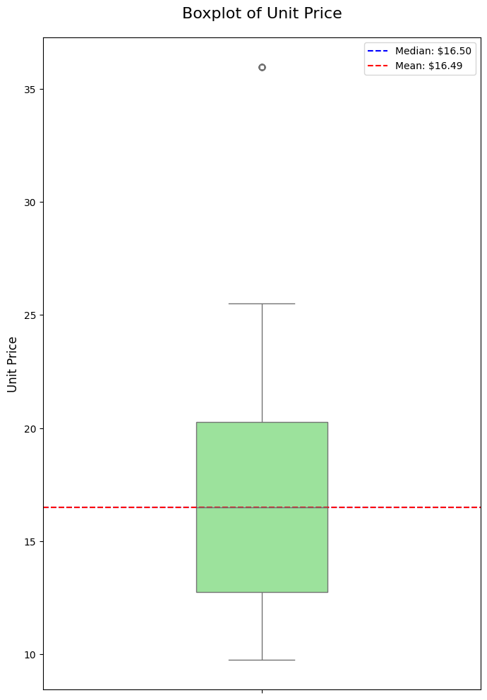

```python
# ===========================================================
# BOX PLOT FOR unit_price, A NUMERIC FEATURE
# HELPS TO DETECT OUTLIERS AND UNDERSTAND DISTRIBUTION SPREAD
# EMULATING THE GIVEN BOX PLOT FORMAT
# ===========================================================

plt.figure(figsize=(8, 12))  # Adjust figure size for vertical orientation
ax = sns.boxplot(y='unit_price', data=df, color="lightgreen", width=0.3)

# CALCULATE STATISTICS
median = df['unit_price'].median()
mean = df['unit_price'].mean()

# ADD MEAN AND MEDIAN LINES
plt.axhline(median, color='blue', linestyle='--', label=f'Median: ${median:.2f}')
plt.axhline(mean, color='red', linestyle='--', label=f'Mean: ${mean:.2f}')

# ADD LEGEND, TITLE, AND LABELS
plt.legend(loc='upper right')
plt.title("Boxplot of Unit Price", fontsize=16, pad=20)
plt.xlabel("")  # Not needed for a vertical boxplot
plt.ylabel("Unit Price", fontsize=12)

# DISPLAY THE PLOT
plt.show()
```

👆 OBSERVATION

- THE BOX REPRESENTS THE MIDDLE 50% OF UNIT PRICES, INDICATING THAT THE BULK OF PRICES ARE BETWEEN APPROX. $13 AND $20.
- THE MEDIAN (~$16.50, BLUE LINE) IS VERY CLOSE TO THE MEAN (~$16.49, RED LINE), SUGGESTING A RELATIVELY SYMMETRIC DISTRIBUTION OF UNIT PRICES.
- OUTLIERS ARE PRESENT ABOVE APPROX. $35, INDICATING RARELY OCCURRING HIGH-PRICE ITEMS.
- THE WHISKERS SHOW THAT MOST DATA FALLS WITHIN ~$10 AND ~$25, REFLECTING A MODERATE RANGE OF UNIT PRICES.

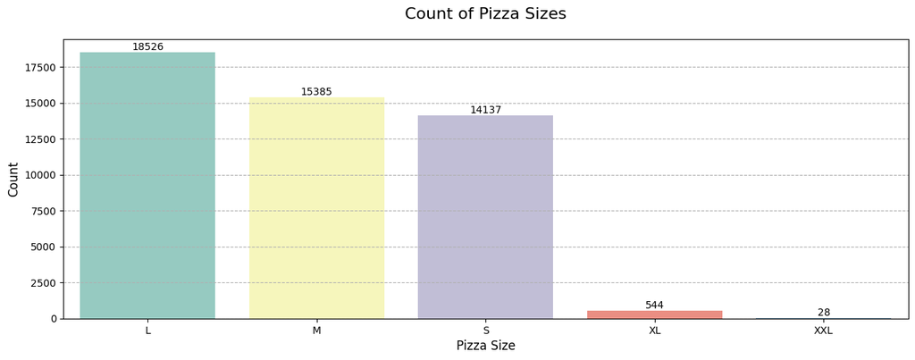

```python
# ================================================
# COUNT PLOT FOR pizza_size, A CATEGORICAL FEATURE
# THE FREQUENCY OF EACH CATEGORY IN PIZZA_SIZE
# EMULATING THE GIVEN COUNT PLOT FORMAT
# ================================================

# EXTRACT VALUE COUNTS AND DERIVE ORDER
size_counts = df['pizza_size'].value_counts()
sorted_sizes = size_counts.index

plt.figure(figsize=(15, 5))
ax = sns.countplot(
    data=df,
    x='pizza_size',
    order=sorted_sizes,
    palette='Set3'
)

# ADD COUNTS ON TOP OF BARS
for p in ax.patches:
    ax.annotate(
        format(p.get_height(), '.0f'),  # Format count as integer
        (p.get_x() + p.get_width() / 2., p.get_height()),  # Position of annotation
        ha='center', va='center', fontsize=10, color='black', xytext=(0, 5), textcoords='offset points'
    )

# ADD TITLE AND LABELS
plt.title("Count of Pizza Sizes", fontsize=16, pad=20)
plt.xlabel("Pizza Size", fontsize=12)
plt.ylabel("Count", fontsize=12)
plt.grid(axis='y', linestyle='--')

# DISPLAY THE PLOT
plt.show()
```

👆 OBSERVATION

- 'L' SIZE PIZZAS ARE THE MOST POPULAR (~18,526 ORDERS), FOLLOWED BY 'M' (~15,385) AND 'S' (~14,137).
- 'XL' AND 'XXL' SIZES ARE RARE, WITH ONLY 544 AND 28 ORDERS RESPECTIVELY.
- THE DISTRIBUTION IS CLEARLY SKEWED TOWARDS REGULAR SIZES (L, M, S) RATHER THAN OVERSIZED OPTIONS.

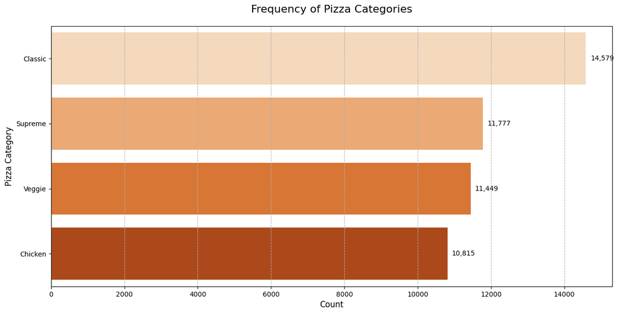

```python
# ==================================================
# BAR PLOT FOR pizza_category, A CATEGORICAL FEATURE
# THE FREQUENCY OF EACH CATEGORY IN PIZZA_CATEGORY
# EMULATING THE GIVEN BARPLOT FORMAT
# ==================================================

category_counts = df['pizza_category'].value_counts().sort_values(ascending=False)

plt.figure(figsize=(15, 7))  # Adjust figure size for clarity
ax = sns.barplot(
    x=category_counts.values,
    y=category_counts.index,
    palette="Oranges"  # Using an orange palette to match original style
)

# ADD VALUES TO THE BARS
for i, value in enumerate(category_counts.values):
    ax.text(
        value + (value * 0.01), i, f"{value:,.0f}",  # Format count as integer with commas
        color="black", va="center", fontsize=10
    )

# ADD TITLE AND LABELS
plt.title("Frequency of Pizza Categories", fontsize=16, pad=20)
plt.xlabel("Count", fontsize=12)
plt.ylabel("Pizza Category", fontsize=12)
plt.grid(axis='x', linestyle='--')

# DISPLAY THE PLOT
plt.show()
```

👆 OBSERVATION

- 'Classic' CATEGORY HAS THE HIGHEST FREQUENCY (~14,579), INDICATING IT IS THE MOST POPULAR PIZZA CATEGORY.
- 'Supreme' AND 'Veggie' CATEGORIES ARE ALSO VERY COMMON, WITH ~11,777 AND ~11,449 ORDERS RESPECTIVELY.
- 'Chicken' IS THE LEAST FREQUENT AMONG THE FOUR, BUT STILL HAS A SUBSTANTIAL COUNT (~10,815).
- THE DISTRIBUTION SUGGESTS THAT ALL FOUR CATEGORIES ARE WELL-REPRESENTED, WITH 'Classic' CLEARLY LEADING.

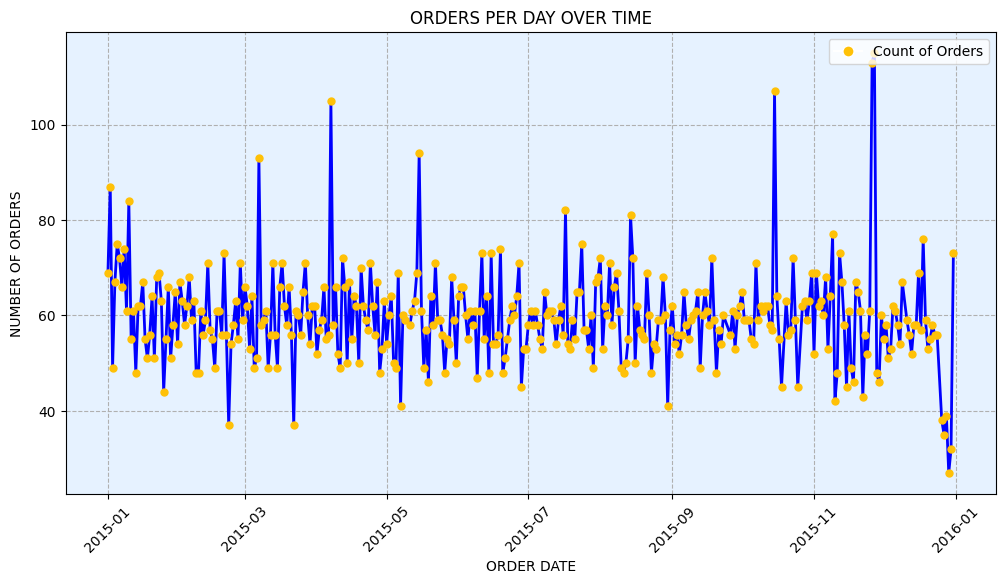

```python
# =======================================================================
# LINE PLOT OF order_date, AN ORDERED TEMPORAL FEATURE
# COUNT THE NUMBER OF ORDERS PER DAY AS A TIME SERIES UNIVARIATE ANALYSIS
# =======================================================================

orders_per_day = df.groupby('order_date')['order_id'].nunique()

plt.figure(figsize=(12, 6))
plt.plot(
    orders_per_day.index,
    orders_per_day.values,
    marker='o',
    markersize=5,
    markerfacecolor='#FFC107',  # Orangish-yellow
    markeredgecolor='#FFC107',
    color='blue',
    linewidth=2
)

# SET A VERY LIGHT PASTEL BLUE BACKGROUND COLOR
plt.gca().set_facecolor('#E6F2FF')  # Pastel blue background
plt.title("ORDERS PER DAY OVER TIME")
plt.xlabel("ORDER DATE")
plt.ylabel("NUMBER OF ORDERS")
plt.grid(True, linestyle='--')
plt.xticks(rotation=45)

# CREATE A CUSTOM LEGEND ENTRY FOR THE ORANGISH-YELLOW DOTS
legend_elements = [Line2D([0], [0], marker='o', color='w', label='Count of Orders',
                          markerfacecolor='#FFC107', markersize=8)]

plt.legend(handles=legend_elements, loc='upper right')

plt.show()
```

👆 OBSERVATION

```python
# ============================================================
# UNIQUE VALUE COUNTS FOR pizza_name_id, A CATEGORICAL FEATURE
# UNDERSTAND THE DIVERSITY OF PIZZA NAMES
# ============================================================

pizza_name_id_counts = df['pizza_name_id'].value_counts()
print("UNIQUE COUNTS FOR PIZZA_NAME_ID:")
print(pizza_name_id_counts.head(10))
```

```
UNIQUE COUNTS FOR PIZZA_NAME_ID:
big_meat_s       1811
thai_ckn_l       1365
five_cheese_l    1359
four_cheese_l    1273
classic_dlx_m    1159
spicy_ital_l     1088
hawaiian_s       1001
southw_ckn_l      993
bbq_ckn_l         967
bbq_ckn_m         926
Name: pizza_name_id, dtype: int64
```

👆 OBSERVATION

- "big_meat_s" appears most frequently (1,811 occurrences), suggesting a popular pizza variant.
- Other top pizza_name_id values include "thai_ckn_l" and "five_cheese_l," indicating strong demand for Thai Chicken and Five Cheese pizzas.
- The top 10 pizza_name_id entries each exceed 900 occurrences, showing these pizzas dominate a large portion of orders.

```python
# ============================================================
# UNIQUE VALUES FOR pizza_ingredients, (A CATEGORICAL FEATURE)
# UNDERSTAND THE DIVERSITY OF PIZZA INGREDIENTS
# ============================================================
df['pizza_ingredients'].unique()
```

```
array(['Sliced Ham, Pineapple, Mozzarella Cheese',
       'Pepperoni, Mushrooms, Red Onions, Red Peppers, Bacon',
       'Mozzarella Cheese, Provolone Cheese, Smoked Gouda Cheese, Romano Cheese, Blue Cheese, Garlic',
       'Calabrese Salami, Capocollo, Tomatoes, Red Onions, Green Olives, Garlic',
       'Tomatoes, Red Peppers, Jalapeno Peppers, Red Onions, Cilantro, Corn, Chipotle Sauce, Garlic',
       'Chicken, Pineapple, Tomatoes, Red Peppers, Thai Sweet Chilli Sauce',
       'Prosciutto di San Daniele, Arugula, Mozzarella Cheese',
       'Barbecued Chicken, Red Peppers, Green Peppers, Tomatoes, Red Onions, Barbecue Sauce',
       'Kalamata Olives, Feta Cheese, Tomatoes, Garlic, Beef Chuck Roast, Red Onions',
       'Spinach, Red Onions, Pepperoni, Tomatoes, Artichokes, Kalamata Olives, Garlic, Asiago Cheese',
       'Spinach, Mushrooms, Tomatoes, Green Olives, Feta Cheese',
       'Capocollo, Red Peppers, Tomatoes, Goat Cheese, Garlic, Oregano',
       'Capocollo, Tomatoes, Goat Cheese, Artichokes, Peperoncini verdi, Garlic',
       'Spinach, Artichokes, Tomatoes, Sun-dried Tomatoes, Garlic, Pesto Sauce',
       'Mushrooms, Tomatoes, Red Peppers, Green Peppers, Red Onions, Zucchini, Spinach, Garlic',
       'Chicken, Tomatoes, Red Peppers, Red Onions, Jalapeno Peppers, Corn, Cilantro, Chipotle Sauce',
       'Chicken, Artichoke, Spinach, Garlic, Jalapeno Peppers, Fontina Cheese, Gouda Cheese',
       'Mozzarella Cheese, Pepperoni',
       'Chicken, Tomatoes, Red Peppers, Spinach, Garlic, Pesto Sauce',
       'Bacon, Pepperoni, Italian Sausage, Chorizo Sausage',
       'Soppressata Salami, Fontina Cheese, Mozzarella Cheese, Mushrooms, Garlic',
       'Ricotta Cheese, Gorgonzola Piccante Cheese, Mozzarella Cheese, Parmigiano Reggiano Cheese, Garlic',
       'Tomatoes, Anchovies, Green Olives, Red Onions, Garlic',
       '?duja Salami, Pancetta, Tomatoes, Red Onions, Friggitello Peppers, Garlic',
       'Eggplant, Artichokes, Tomatoes, Zucchini, Red Peppers, Garlic, Pesto Sauce',
       'Spinach, Artichokes, Kalamata Olives, Sun-dried Tomatoes, Feta Cheese, Plum Tomatoes, Red Onions',
       'Genoa Salami, Capocollo, Pepperoni, Tomatoes, Asiago Cheese, Garlic',
       'Spinach, Mushrooms, Red Onions, Feta Cheese, Garlic',
       'Coarse Sicilian Salami, Tomatoes, Green Olives, Luganega Sausage, Onions, Garlic',
       'Chicken, Red Onions, Red Peppers, Mushrooms, Asiago Cheese, Alfredo Sauce',
       'Pepperoni, Mushrooms, Green Peppers',
       'Brie Carre Cheese, Prosciutto, Caramelized Onions, Pears, Thyme, Garlic'],
      dtype=object)
```

👆 OBSERVATION

### **Feature Engineering**

```python
# =====================================================
# FEATURE EXTRACTION FOR CATEGORICAL/TEXTUAL DATA
# INGREDIENTS: COUNT FREQUENCY OF INDIVIDUAL INGREDIENTS
# =====================================================

# THE GOAL:
# - DETERMINE THE CORRECT DELIMITER (" ,") FOR INGREDIENTS
# - SPLIT THE 'pizza_ingredients' COLUMN INTO INDIVIDUAL INGREDIENTS
# - CHECK IF THERE ARE LEADING/TRAILING SPACES
# - CLEAN AND STANDARDIZE THE INGREDIENT NAMES
# - COUNT FREQUENCY OF EACH INGREDIENT

# IMPORTANT NOTE:
# INITIAL ATTEMPTS SHOWED THAT SPLITTING BY JUST "," LEFT LEADING SPACES.
# THEREFORE, THE CHOSEN DELIMITER IS ", " (COMMA + SPACE) FOR A CLEANER SEPARATION.
```

```python
# ============================================================
# CREATE A SERIES OF ALL INGREDIENTS FROM ALL PIZZAS
# SPLIT THE 'pizza_ingredients' COLUMN BY ", " (COMMA + SPACE)
# THEN EXPLODE THE LISTS INTO INDIVIDUAL ROWS
# ============================================================
all_ingredients = (
    df['pizza_ingredients']
    .apply(lambda x: x.split(', '))  # split by comma + space for cleaner separation
    .explode()                       # transform lists into separate rows
)

all_ingredients
```

```
0               Sliced Ham
0                Pineapple
0        Mozzarella Cheese
1                Pepperoni
1                Mushrooms
               ...
48619          Red Peppers
48619        Green Peppers
48619             Tomatoes
48619           Red Onions
48619       Barbecue Sauce
Name: pizza_ingredients, Length: 267576, dtype: object
```

```python
# ========================================================
# CHECK FOR LEADING AND TRAILING SPACES
# CONFIRM THAT SPLITTING BY ", " ELIMINATED SPACING ISSUES
# ========================================================
starts_with_space = all_ingredients.str.startswith(' ').any()
ends_with_space = all_ingredients.str.endswith(' ').any()

print("Any ingredient starts with a space:", starts_with_space)
print("Any ingredient ends with a space:", ends_with_space)
```

```
Any ingredient starts with a space: False
Any ingredient ends with a space: False
```

```python
# ===========================================================
# ADDITIONAL CLEANING STEPS
# ENSURE CONSISTENT CASING AND REMOVE TRAILING/LEADING SPACES
# (NOT STRICTLY NECESSARY, BUT THIS STEP ENSURES UNIFORMITY)
# ===========================================================
all_ingredients = all_ingredients.str.strip().str.lower()

all_ingredients
```

```
0               sliced ham
0                pineapple
0        mozzarella cheese
1                pepperoni
1                mushrooms
               ...
48619          red peppers
48619        green peppers
48619             tomatoes
48619           red onions
48619       barbecue sauce
Name: pizza_ingredients, Length: 267576, dtype: object
```

```python
# ======================================
# COUNT THE FREQUENCY OF EACH INGREDIENT
# ======================================
ingredient_counts = all_ingredients.value_counts()
ingredient_counts
```

```
garlic                        27422
tomatoes                      26601
red onions                    19547
red peppers                   16284
mozzarella cheese             10333
pepperoni                     10300
spinach                       10012
mushrooms                      9624
chicken                        8443
capocollo                      6572
green olives                   6174
artichokes                     5682
jalapeno peppers               5643
green peppers                  5224
feta cheese                    4748
pineapple                      4685
bacon                          4227
asiago cheese                  3342
cilantro                       3341
corn                           3341
chipotle sauce                 3341
goat cheese                    3301
kalamata olives                3269
fontina cheese                 3259
pesto sauce                    2893
zucchini                       2485
barbecued chicken              2372
barbecue sauce                 2372
sliced ham                     2370
thai sweet chilli sauce        2315
artichoke                      2302
gouda cheese                   2302
onions                         1887
luganega sausage               1887
coarse sicilian salami         1887
peperoncini verdi              1887
sun-dried tomatoes             1880
gorgonzola piccante cheese     1850
parmigiano reggiano cheese     1850
ricotta cheese                 1850
```

[output cut: 11 more lines]

```
romano cheese                  1359
blue cheese                    1359
alfredo sauce                   980
eggplant                        975
soppressata salami              957
friggitello peppers             927
pancetta                        927
?duja salami                    927
plum tomatoes                   923
brie carre cheese               480
prosciutto                      480
caramelized onions              480
pears                           480
thyme                           480
Name: pizza_ingredients, dtype: int64
```

👆 OBSERVATION

- THE LIST DISPLAYS INGREDIENTS IN DESCENDING ORDER OF FREQUENCY, INDICATING WHICH INGREDIENTS ARE MOST COMMON.
- THE NUMBERS REPRESENT THE TOTAL NUMBER OF TIMES EACH INGREDIENT APPEARS ACROSS ALL PIZZA ORDERS IN THE DATASET.
- INGREDIENTS LIKE GARLIC AND TOMATOES HAVE VERY HIGH COUNTS (27,422 AND 26,601 RESPECTIVELY), SUGGESTING THEY ARE STAPLE INGREDIENTS IN MANY PIZZAS.
- INGREDIENTS WITH LOWER COUNTS, SUCH AS PEARS OR THYME (480 OCCURRENCES), ARE RARER, INDICATING THEY ARE USED LESS FREQUENTLY.

```python
# =================================================================
# //COMBINE order_date AND order_time INTO A SINGLE DATETIME COLUMN
# //DROP THE ORIGINAL order_date COLUMN
# //DISPLAY THE FIRST FEW ROWS OF THE MODIFIED df DATAFRAME
# =================================================================
df['order_time'] = df['order_date'].combine(
    df['order_time'],
    lambda d, t: d.replace(hour=t.hour, minute=t.minute, second=t.second)
)
df.drop(columns=['order_date'], inplace=True)
df.head()
```

|  | pizza_id | order_id | pizza_name_id | quantity | order_time | unit_price | total_price | pizza_size | pizza_category | pizza_ingredients | pizza_name |
| --- | --- | --- | --- | --- | --- | --- | --- | --- | --- | --- | --- |
| 0 | 1.0 | 1.0 | hawaiian_m | 1.00 | 2015-01-01 11:38:36 | 13.25 | 13.25 | M | Classic | Sliced Ham, Pineapple, Mozzarella Cheese | The Hawaiian Pizza |
| 1 | 2.0 | 2.0 | classic_dlx_m | 1.00 | 2015-01-01 11:57:40 | 16.00 | 16.00 | M | Classic | Pepperoni, Mushrooms, Red Onions, Red Peppers,... | The Classic Deluxe Pizza |
| 2 | 3.0 | 2.0 | five_cheese_l | 1.00 | 2015-01-01 11:57:40 | 18.50 | 18.50 | L | Veggie | Mozzarella Cheese, Provolone Cheese, Smoked Go... | The Five Cheese Pizza |
| 3 | 4.0 | 2.0 | ital_supr_l | 1.00 | 2015-01-01 11:57:40 | 20.75 | 20.75 | L | Supreme | Calabrese Salami, Capocollo, Tomatoes, Red Oni... | The Italian Supreme Pizza |
| 4 | 5.0 | 2.0 | mexicana_m | 1.00 | 2015-01-01 11:57:40 | 16.00 | 16.00 | M | Veggie | Tomatoes, Red Peppers, Jalapeno Peppers, Red O... | The Mexicana Pizza |

👆 OBSERVATION

- THE order_date COLUMN HAS BEEN REMOVED, AND A UNIFIED order_time COLUMN NOW REPRESENTS BOTH DATE AND TIME.
- THE MODIFIED DATAFRAME SHOWS THAT ORDER TIMING IS PRECISELY CAPTURED WITH HOURS, MINUTES, AND SECONDS.
- ALL OTHER ORIGINAL FEATURES REMAIN, ENSURING CONTINUITY OF THE DATA WHILE ENHANCING TEMPORAL ANALYSIS CAPABILITY.

```python
# ====================================================
# //EXTRACT MONTH FROM order_time INTO order_month
# //CLASSIFY order_time INTO time_of_day BASED ON HOUR:
# //     MORNING = 6 < HOUR < 12
# //     AFTERNOON = 12 < HOUR < 18
# //     EVENING = OTHERWISE
# //DISPLAY FIRST FEW ROWS OF MODIFIED DATAFRAME
# ====================================================
df['order_month'] = df['order_time'].dt.month

df['time_of_day'] = df['order_time'].dt.hour.apply(
    lambda x: "Morning" if 6 < x < 12
    else ("Afternoon" if 12 < x < 18
    else "Evening")
)

df.head()
```

|  | pizza_id | order_id | pizza_name_id | quantity | order_time | unit_price | total_price | pizza_size | pizza_category | pizza_ingredients | pizza_name | order_month | time_of_day |
| --- | --- | --- | --- | --- | --- | --- | --- | --- | --- | --- | --- | --- | --- |
| 0 | 1.0 | 1.0 | hawaiian_m | 1.00 | 2015-01-01 11:38:36 | 13.25 | 13.25 | M | Classic | Sliced Ham, Pineapple, Mozzarella Cheese | The Hawaiian Pizza | 1 | Morning |
| 1 | 2.0 | 2.0 | classic_dlx_m | 1.00 | 2015-01-01 11:57:40 | 16.00 | 16.00 | M | Classic | Pepperoni, Mushrooms, Red Onions, Red Peppers,... | The Classic Deluxe Pizza | 1 | Morning |
| 2 | 3.0 | 2.0 | five_cheese_l | 1.00 | 2015-01-01 11:57:40 | 18.50 | 18.50 | L | Veggie | Mozzarella Cheese, Provolone Cheese, Smoked Go... | The Five Cheese Pizza | 1 | Morning |
| 3 | 4.0 | 2.0 | ital_supr_l | 1.00 | 2015-01-01 11:57:40 | 20.75 | 20.75 | L | Supreme | Calabrese Salami, Capocollo, Tomatoes, Red Oni... | The Italian Supreme Pizza | 1 | Morning |
| 4 | 5.0 | 2.0 | mexicana_m | 1.00 | 2015-01-01 11:57:40 | 16.00 | 16.00 | M | Veggie | Tomatoes, Red Peppers, Jalapeno Peppers, Red O... | The Mexicana Pizza | 1 | Morning |

👆 OBSERVATION

- A NEW order_month COLUMN SUCCESSFULLY EXTRACTS THE MONTH AS A NUMERIC VALUE, FACILITATING MONTHLY TREND ANALYSIS.
- A NEW time_of_day COLUMN CLASSIFIES ORDERS INTO MORNING, AFTERNOON, OR EVENING, ADDING A USEFUL CATEGORICAL TIME FEATURE.
- THE DATAFRAME NOW PROVIDES MORE GRANULAR TIME-BASED INSIGHTS WITHOUT ALTERING OTHER EXISTING FEATURES.

### **Bivariate Analysis**

```python
# ================================================================
# CREATE A CONTINGENCY TABLE BETWEEN pizza_size AND pizza_category
# ================================================================

contingency_table = pd.crosstab(df['pizza_size'], df['pizza_category'])
print("CONTINGENCY TABLE: pizza_size vs pizza_category")
print(contingency_table)
```

```
CONTINGENCY TABLE: pizza_size vs pizza_category
pizza_category  Chicken  Classic  Supreme  Veggie
pizza_size
L                  4799     3987     4477    5263
M                  3811     4045     3977    3552
S                  2205     5975     3323    2634
XL                    0      544        0       0
XXL                   0       28        0       0
```

👆 OBSERVATION

- THE CONTINGENCY TABLE SHOWS THE DISTRIBUTION OF PIZZA SIZES ACROSS DIFFERENT CATEGORIES, INDICATING WHICH SIZES ARE MOST FREQUENTLY ASSOCIATED WITH EACH CATEGORY.
- 'L' AND 'M' SIZES ARE COMMON ACROSS ALL CATEGORIES, WHILE 'XL' AND 'XXL' ARE RARE, APPEARING ONLY IN 'Classic' CATEGORY.
- 'S' SIZE SEEMS ESPECIALLY POPULAR IN THE 'Classic' CATEGORY, SUGGESTING A PREFERENCE FOR SMALL CLASSIC PIZZAS.

```python
# =========================================================
# GROUPBY order_month AND pizza_category TO SUM total_price
# AGGREGATE SALES PERFORMANCE ACROSS CATEGORIES BY MONTH
# =========================================================

monthly_sales = df.groupby(['order_month', 'pizza_category'])['total_price'].sum().unstack()
print("MONTHLY SALES BY CATEGORY:")
print(monthly_sales)
```

```
MONTHLY SALES BY CATEGORY:
pizza_category  Chicken  Classic  Supreme   Veggie
order_month
1              16696.25 19236.40 18324.85 17362.65
2              16273.25 17209.10 16066.85 14870.25
3              17055.75 19119.85 17457.25 17668.55
4              17113.50 19137.90 17566.90 16493.70
5              16174.25 18223.35 17761.65 15489.55
6              16212.50 18307.40 17690.35 15951.20
7              16699.50 19106.70 18294.25 16780.20
8              16579.50 19003.45 17699.45 16214.90
9              16417.50 17710.10 15344.65 14331.45
10             15690.00 18281.35 18146.20 16034.65
11             16472.25 18303.85 18555.00 17673.75
12             14535.25 16413.65 15289.60 14819.60
```

👆 OBSERVATION

- THE GROUPED SALES DATA BY MONTH AND CATEGORY REVEALS FLUCTUATIONS IN REVENUE ACROSS DIFFERENT SEASONS.
- 'Classic' AND 'Supreme' CATEGORIES GENERATE CONSISTENTLY HIGH SALES THROUGHOUT THE YEAR, WITH PEAKS IN CERTAIN MONTHS.
- 'Veggie' AND 'Chicken' SALES ALSO VARY MONTH-TO-MONTH, BUT ALL CATEGORIES SHOW A RELATIVELY EVEN SPREAD, SUGGESTING NO SINGLE CATEGORY DOMINATES YEAR-ROUND SALES.
- THIS TABLE PROVIDES A FOUNDATION FOR IDENTIFYING SEASONAL TRENDS AND INFORMING INVENTORY OR PROMOTIONAL STRATEGIES.

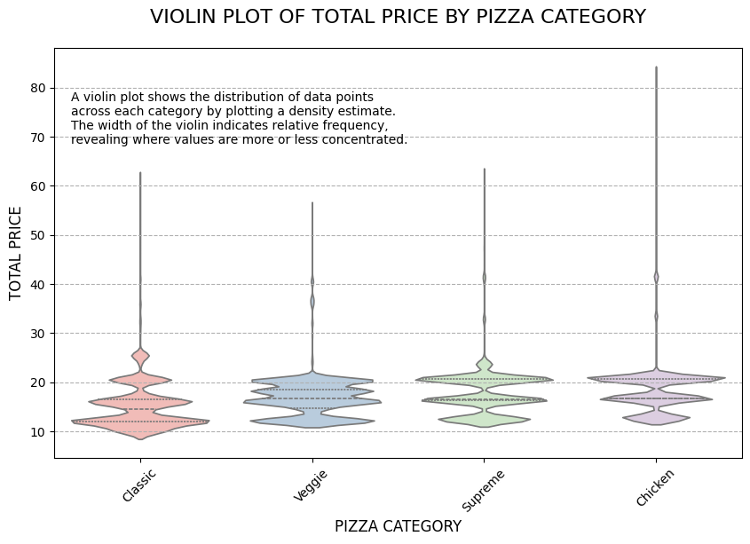

```python
# ==========================================================
# VIOLIN PLOT OF TOTAL PRICE BY PIZZA CATEGORY
# THIS PLOT REVEALS THE DISTRIBUTION AND KERNEL DENSITY ESTIMATE OF TOTAL PRICE
# SHOWING WHERE DATA POINTS ARE MORE CONCENTRATED VERTICALLY
# ==========================================================

plt.figure(figsize=(10, 6))
ax = sns.violinplot(
    x="pizza_category",
    y="total_price",
    data=df,
    palette="Pastel1",
    inner="quartile"  # Show quartiles inside the violin
)

# ADD GRID
plt.grid(axis='y', linestyle='--')

# ADD TITLE AND LABELS
plt.title("VIOLIN PLOT OF TOTAL PRICE BY PIZZA CATEGORY", fontsize=16, pad=20)
plt.xlabel("PIZZA CATEGORY", fontsize=12)
plt.ylabel("TOTAL PRICE", fontsize=12)
plt.xticks(rotation=45)

# ADD ANNOTATION EXPLAINING VIOLIN PLOT IN THE UPPER LEFT CORNER
annotation_text = (
    "A violin plot shows the distribution of data points\n"
    "across each category by plotting a density estimate.\n"
    "The width of the violin indicates relative frequency,\n"
    "revealing where values are more or less concentrated."
)
plt.text(
    -0.4,  # a bit left of the first category
    plt.ylim()[1]*0.9,  # near the top of the y-axis limit
    annotation_text,
    fontsize=10,
    color="black",
    va="top"  # align top edge of the text to chosen position
)

plt.show()
```

👆 OBSERVATION

- EACH VIOLIN REPRESENTS THE DISTRIBUTION OF TOTAL PRICE WITHIN A SPECIFIC PIZZA CATEGORY, SHOWING WHERE MOST ORDERS CLUSTER AND HOW WIDELY THEY VARY.
- THE VIOLINS ARE NOT SYMMETRICAL AROUND A SINGLE MEDIAN LINE; INSTEAD, THEIR WIDTH AT ANY GIVEN PRICE LEVEL INDICATES THE RELATIVE FREQUENCY OF ORDERS AT THAT PRICE.
- DESPITE SOME CATEGORIES STRETCHING HIGHER IN PRICE, THE MAJORITY OF ORDERS REMAIN NEAR THE LOWER END, INDICATING THAT MOST CUSTOMERS ORDER WITHIN A RELATIVELY NARROW PRICE RANGE.

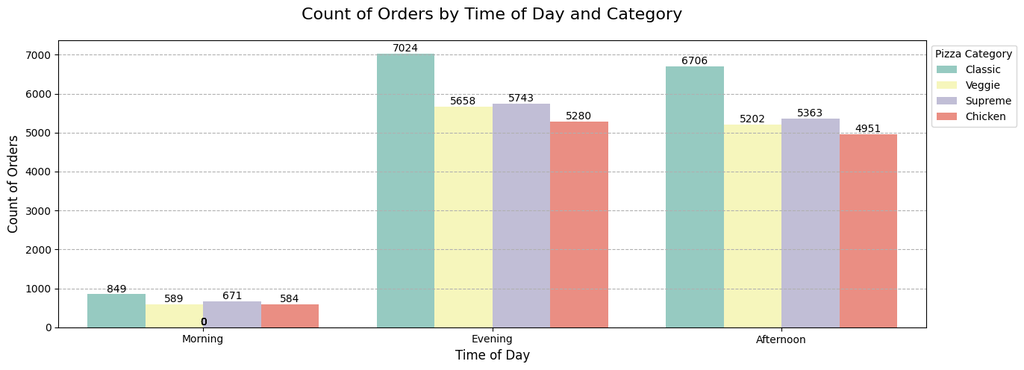

```python
# ================================================================
# COUNT PLOT OF time_of_day BY pizza_category
# FREQUENCY OF ORDERS ACROSS DIFFERENT TIMES OF DAY AND CATEGORIES
# ================================================================

plt.figure(figsize=(15, 5))  # Adjust figure size for clarity
ax = sns.countplot(
    x='time_of_day',
    hue='pizza_category',
    data=df,
    palette='Set3'
)

# ADD COUNTS ON TOP OF BARS
for p in ax.patches:
    ax.annotate(
        format(p.get_height(), '.0f'),
        (p.get_x() + p.get_width() / 2., p.get_height()),
        ha='center', va='center', fontsize=10, color='black', xytext=(0, 5), textcoords='offset points'
    )

# ADD TITLE AND LABELS
plt.title("Count of Orders by Time of Day and Category", fontsize=16, pad=20)
plt.xlabel("Time of Day", fontsize=12)
plt.ylabel("Count of Orders", fontsize=12)

# ADD GRID AND LEGEND
plt.grid(axis='y', linestyle='--')
plt.legend(title='Pizza Category', bbox_to_anchor=(1, 1))

# DISPLAY THE PLOT
plt.show()
```

👆 OBSERVATION

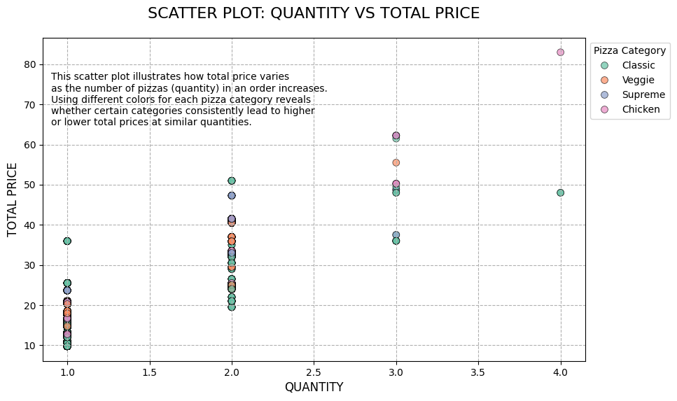

```python
# ===========================================================
# SCATTER PLOT: QUANTITY VS TOTAL PRICE
# ADD A THIRD ATTRIBUTE (HUE = PIZZA_CATEGORY) TO PROVIDE MORE INSIGHT
# ADD ANNOTATION EXPLAINING THE PLOT IN THE UPPER LEFT CORNER
# ===========================================================

plt.figure(figsize=(10, 6))

# USE HUE TO DIFFERENTIATE BY pizza_category, GAINING EXTRA INSIGHT
ax = sns.scatterplot(
    x='quantity',
    y='total_price',
    data=df,
    hue='pizza_category',
    palette='Set2',   # Add some color variety
    alpha=0.7,        # Slight transparency for overlapping points
    edgecolor='black',
    s=50              # Increase size for better visibility
)

plt.title("SCATTER PLOT: QUANTITY VS TOTAL PRICE", fontsize=16, pad=20)
plt.xlabel("QUANTITY", fontsize=12)
plt.ylabel("TOTAL PRICE", fontsize=12)
plt.grid(True, linestyle='--')

# ADD ANNOTATION IN THE UPPER LEFT CORNER TO EXPLAIN THE PLOT
annotation_text = (
    "This scatter plot illustrates how total price varies\n"
    "as the number of pizzas (quantity) in an order increases.\n"
    "Using different colors for each pizza category reveals\n"
    "whether certain categories consistently lead to higher\n"
    "or lower total prices at similar quantities."
)

plt.text(
    0.9,   # Adjust x-position as needed
    plt.ylim()[1] * 0.9,  # Place near the top of the plot
    annotation_text,
    fontsize=10,
    color="black",
    va="top",
    ha="left"
)

plt.legend(title='Pizza Category', bbox_to_anchor=(1, 1))
plt.show()
```

👆 OBSERVATION

- THE SCATTER PLOT USES COLOR CODING (HUE) TO DIFFERENTIATE PIZZA CATEGORIES, MAKING IT EASIER TO SEE IF SPECIFIC CATEGORIES CONSISTENTLY CORRELATE WITH HIGHER OR LOWER TOTAL PRICES AT THE SAME QUANTITY.
- ORDERS WITH THE SAME QUANTITY STILL EXHIBIT A RANGE OF TOTAL PRICES, BUT THE COLOR GROUPINGS PROVIDE CLUES THAT SOME CATEGORIES MAY TEND TOWARDS HIGHER OR LOWER PRICE POINTS THAN OTHERS.

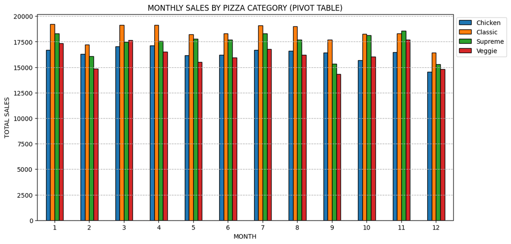

```python
# ========================================================
# PIVOT TABLE & BAR PLOT FOR ORDER_MONTH AND pizza_category
# CREATE A PIVOT TABLE AND THEN PLOT A CLUSTERED BAR CHART
# SHOWING COMPARISON OF CATEGORIES ACROSS MONTHS
# ========================================================

pivot_data = df.pivot_table(values='total_price', index='order_month', columns='pizza_category', aggfunc='sum', fill_value=0)
pivot_data.plot(kind='bar', figsize=(12, 6), edgecolor='black')
plt.title("MONTHLY SALES BY PIZZA CATEGORY (PIVOT TABLE)")
plt.xlabel("MONTH")
plt.ylabel("TOTAL SALES")
plt.grid(axis='y', linestyle='--')
plt.xticks(rotation=0)
plt.legend(bbox_to_anchor=(1,1))
plt.show()
```

👆 OBSERVATION

- ALL FOUR PIZZA CATEGORIES (CHICKEN, CLASSIC, SUPREME, VEGGIE) DEMONSTRATE CONSISTENT MONTHLY SALES THROUGHOUT THE YEAR, WITH RELATIVELY HIGH TOTALS EVERY MONTH.
- THERE ARE NO EXTREME SPIKES OR DRASTIC DIPS; INSTEAD, THE CATEGORIES REMAIN FAIRLY BALANCED AND COMPETITIVE, SUGGESTING STEADY DEMAND ACROSS SEASONS.
- SOME MONTHS SHOW SLIGHT LEADERSHIP OF ONE CATEGORY OVER ANOTHER, BUT OVERALL, SALES LEVELS APPEAR STABLE AND RELATIVELY SIMILAR AMONG ALL FOUR CATEGORIES.

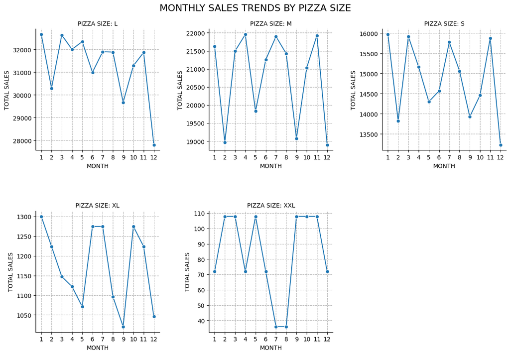

```python
import warnings
warnings.filterwarnings("ignore", category=FutureWarning)  # Suppress future warnings
# ==================================================
# FACETGRID LINE PLOT OF MONTHLY SALES BY PIZZA_SIZE
# SHOWS TRENDS OVER TIME FOR DIFFERENT SIZES
# MULTI-PLOT GRID BASED ON PIZZA_SIZE
# ==================================================

# CREATE THE DATAFRAME FOR FACET PLOTS
facet_data = df.groupby(['order_month', 'pizza_size'])['total_price'].sum().reset_index()

# MAKE SURE order_month IS TREATED AS WHOLE INTEGERS
facet_data['order_month'] = facet_data['order_month'].astype(int)

# CREATE THE FACETGRID
g = sns.FacetGrid(facet_data, col='pizza_size', col_wrap=3, height=4, sharey=False, sharex=False)

# PLOT THE DATA
g.map_dataframe(sns.lineplot, x='order_month', y='total_price', marker='o')

# SET TITLES AND LABELS
g.set_titles(col_template="PIZZA SIZE: {col_name}")
# We won't rely solely on set_axis_labels because we need each subplot to have labels visible
# Instead, we'll set them manually per axis
#g.set_axis_labels("MONTH", "TOTAL SALES")

# ADJUST SPACING BETWEEN SUBPLOTS FOR AXIS LABEL VISIBILITY
g.fig.subplots_adjust(hspace=0.5, wspace=0.4)

# ADD A MAIN TITLE FOR THE ENTIRE FIGURE
g.fig.suptitle("MONTHLY SALES TRENDS BY PIZZA SIZE", fontsize=16, y=1.03)

# MANUALLY SET TICKS AND LABELS FOR EACH SUBPLOT
for ax in g.axes.flat:
    # Set integer x-ticks from 1 to 12 (assuming months 1 through 12)
    ax.set_xticks(range(1, 13))
    ax.set_xlabel("MONTH", fontsize=10)   # Ensure each plot shows x-label
    ax.set_ylabel("TOTAL SALES", fontsize=10)  # Ensure each plot shows y-label
    ax.tick_params(axis='x', labelrotation=0)
    ax.grid(True, linestyle='--')

plt.show()
```

👆 OBSERVATION

- EACH PIZZA SIZE PLOT DISPLAYS CLEARLY LABELED MONTHS (1 THROUGH 12), ALLOWING EASY COMPARISON OF SALES MAGNITUDES ACROSS DIFFERENT PIZZA SIZES.
- WHILE MONTH-TO-MONTH VARIABILITY EXISTS, THE INDIVIDUAL SUBPLOTS PROVIDE A BETTER UNDERSTANDING OF SALES FLUCTUATIONS SPECIFIC TO EACH SIZE, REVEALING DISTINCT PATTERNS AND PEAKS THROUGHOUT THE YEAR.

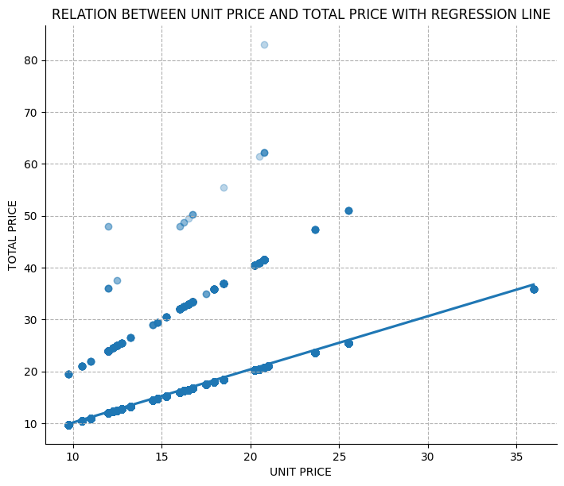

```python
# ==============================================================================
# REG PLOT OR LM PLOT TO ANALYZE RELATIONSHIP BETWEEN unit_price AND total_price
# FITS A REGRESSION LINE, SHOWING TRENDS AND CONFIDENCE INTERVAL
# ==============================================================================

sns.lmplot(x='unit_price', y='total_price', data=df, height=6, aspect=1.2, scatter_kws={'alpha':0.3})
plt.title("RELATION BETWEEN UNIT PRICE AND TOTAL PRICE WITH REGRESSION LINE")
plt.xlabel("UNIT PRICE")
plt.ylabel("TOTAL PRICE")
plt.grid(True, linestyle='--')
plt.show()
```

👆 OBSERVATION

- THE REGRESSION LINE SUGGESTS A POSITIVE RELATIONSHIP BETWEEN UNIT PRICE AND TOTAL PRICE, MEANING THAT AS UNIT PRICE INCREASES, THE TOTAL PRICE TENDS TO RISE.
- THE DATA POINTS DISPLAY VARYING LEVELS OF SCATTER; SOME VALUES AT HIGHER UNIT PRICES APPEAR FAR ABOVE THE MAIN CLUSTER, INDICATING THAT CERTAIN PIZZA ORDERS MAY HAVE MULTIPLE HIGH-PRICED ITEMS OR ADDITIONS.
- ALTHOUGH A LINEAR TREND EXISTS, THE PRESENCE OF OUTLIERS AND POINTS FAR FROM THE LINE SUGGESTS FACTORS BEYOND UNIT PRICE MAY INFLUENCE THE TOTAL PRICE, OR THAT NON-LINEAR RELATIONSHIPS MIGHT BE AT PLAY.

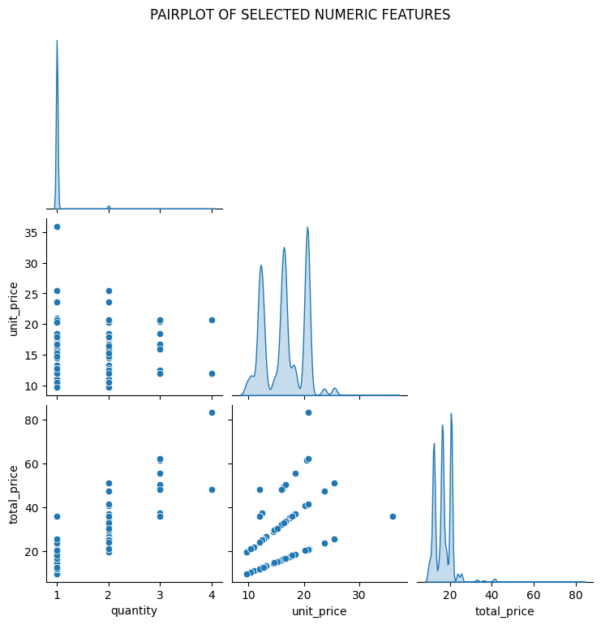

```python
# ===============================================================
# PAIRPLOT OF SELECTED NUMERIC COLUMNS
# EXAMINE PAIRWISE RELATIONSHIPS ACROSS MULTIPLE NUMERIC FEATURES
# ===============================================================

selected_numeric = df[['quantity', 'unit_price', 'total_price']]
sns.pairplot(selected_numeric, diag_kind='kde', corner=True)
plt.suptitle("PAIRPLOT OF SELECTED NUMERIC FEATURES", y=1.02)
plt.show()
```

👆 OBSERVATION

- THE pairplot REVEALS DISTINCT DISTRIBUTIONS: quantity IS MOSTLY CLUSTERED BETWEEN 1 AND 2, unit_price SHOWS MULTIPLE PEAKS AT SPECIFIC PRICE LEVELS, AND total_price IS HEAVILY CONCENTRATED TOWARDS LOWER VALUES WITH A FEW OUTLIERS FAR ABOVE THE MAIN CLUSTER.
- SCATTER PLOTS SUGGEST THAT HIGH total_price OFTEN CORRESPOND WITH HIGH unit_price, THOUGH THE RELATIONSHIP IS NOT PERFECT, WHILE quantity EXERTS A SUBTLE INFLUENCE SINCE MOST ORDERS INVOLVE FEW ITEMS.
- THE KERNEL DENSITY PLOTS ON THE DIAGONAL HIGHLIGHT THE SKEWED NATURE OF THE DISTRIBUTIONS FOR unit_price AND total_price, INDICATING THAT MOST ORDERS ARE SIMILARLY PRICED BUT A MINORITY DRIVE UP THE MAXIMUM VALUES.

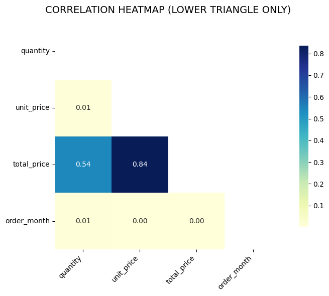

```python
# =======================================
# CORRELATION HEATMAP OF NUMERIC FEATURES
# =======================================
numeric_cols = df.select_dtypes(include=[np.number])
corr = numeric_cols.corr()
mask = np.triu(np.ones_like(corr, dtype=bool))

plt.figure(figsize=(8, 6))
ax = sns.heatmap(
    corr,
    mask=mask,          # Apply the mask to hide the upper triangle
    annot=True,
    cmap='YlGnBu',
    fmt='.2f',
    square=True,
    cbar_kws={'shrink': 0.8}
)

plt.xticks(rotation=45, ha='right')
plt.yticks(rotation=0)
plt.title("CORRELATION HEATMAP (LOWER TRIANGLE ONLY)", fontsize=14, pad=15)
plt.tight_layout()
ax.set_ylim(len(corr), 0)  # Ensure all rows are visible
plt.show()
```

👆 OBSERVATION

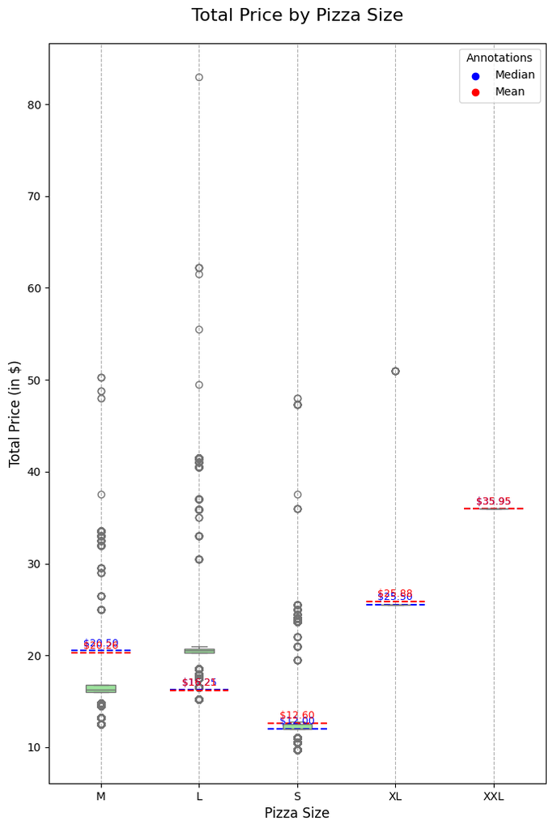

```python
# ======================================================
# BOXPLOT FOR total_price BY pizza_size
# VERTICAL ORIENTATION AND ANNOTATIONS FOR MEAN & MEDIAN
# ======================================================

plt.figure(figsize=(8, 12))  # Vertical orientation
ax = sns.boxplot(y='total_price', x='pizza_size', data=df, color="lightgreen", width=0.3)

# CALCULATE STATISTICS
median_vals = df.groupby('pizza_size')['total_price'].median()
mean_vals = df.groupby('pizza_size')['total_price'].mean()

# ADD HORIZONTAL LINES FOR MEDIAN & MEAN PER CATEGORY
# NOTE: Since we're using a vertical boxplot with 'pizza_size' on the x-axis
# and 'total_price' on the y-axis, we'll draw lines at median and mean by looping categories.
for i, size in enumerate(median_vals.index):
    # Median line at median_vals[size]
    ax.plot([i-0.3, i+0.3], [median_vals[size], median_vals[size]], color='blue', linestyle='--')
    ax.text(i, median_vals[size] + 0.5, f"${median_vals[size]:.2f}", ha='center', fontsize=9, color='blue')

    # Mean line at mean_vals[size]
    ax.plot([i-0.3, i+0.3], [mean_vals[size], mean_vals[size]], color='red', linestyle='--')
    ax.text(i, mean_vals[size] + 0.5, f"${mean_vals[size]:.2f}", ha='center', fontsize=9, color='red')

# ADD TITLE, LABELS
plt.title("Total Price by Pizza Size", fontsize=16, pad=20)
plt.xlabel("Pizza Size", fontsize=12)
plt.ylabel("Total Price (in $)", fontsize=12)

# ADD LEGEND FOR MEAN AND MEDIAN (SIMILAR APPROACH AS #ZZZ)
plt.scatter([], [], color="blue", label="Median")
plt.scatter([], [], color="red", label="Mean")
plt.legend(loc="upper right", title="Annotations")

plt.grid(axis='x', linestyle='--')  # Grid along x-axis for vertical clarity

plt.show()
```

👆 OBSERVATION

- THE BOXPLOT APPEARS SQUASHED BECAUSE EXTREME OUTLIERS IN TOTAL PRICE STRETCH THE Y-AXIS SCALE, MAKING MOST DATA POINTS CLUSTER NEAR THE LOWER END.
- FURTHER INVESTIGATION IS NEEDED TO UNDERSTAND THE MAGNITUDE AND FREQUENCY OF THESE OUTLIERS. A SEPARATE CODE BLOCK THAT DISPLAYS DESCRIPTIVE STATISTICS OR USES DF.DESCRIBE() WOULD PROVIDE INSIGHT INTO THE DATA RANGE AND IQR.
- HANDLING OUTLIERS MAY INVOLVE REMOVING EXTREME VALUES, CAPPING THEM AT A THRESHOLD, OR APPLYING LOG TRANSFORMATION) TO REDUCE THE IMPACT ON SCALING AND IMPROVE VISUAL READABILITY.

```python
# ==============================================
# VIEW DESCRIPTIVE STATISTICS FOR total_price
# IDENTIFY POTENTIAL RANGE AND SCALE OF OUTLIERS
# ==============================================
df['total_price'].describe()
```

```
count   48620.00
mean       16.82
std         4.44
min         9.75
25%        12.75
50%        16.50
75%        20.50
max        83.00
Name: total_price, dtype: float64
```

```python
# =========================================================
# IDENTIFY OUTLIERS USING THE INTERQUARTILE RANGE (IQR)
# POINTS BEYOND 1.5 * IQR ABOVE Q3 OR BELOW Q1 ARE OUTLIERS
# =========================================================
Q1 = df['total_price'].quantile(0.25)
Q3 = df['total_price'].quantile(0.75)
IQR = Q3 - Q1

lower_bound = Q1 - 1.5 * IQR
upper_bound = Q3 + 1.5 * IQR

print("Q1:", Q1)
print("Q3:", Q3)
print('\n')
print("IQR:", IQR)
print('\n')
print("Lower Bound:", lower_bound)
print("Upper Bound:", upper_bound)
print('\n')
# COUNT OUTLIERS
outliers_lower = (df['total_price'] < lower_bound).sum()
outliers_upper = (df['total_price'] > upper_bound).sum()

print("Number of Outliers Below Lower Bound:", outliers_lower)
print("Number of Outliers Above Upper Bound:", outliers_upper)
```

```
Q1: 12.75
Q3: 20.5


IQR: 7.75


Lower Bound: 1.125
Upper Bound: 32.125


Number of Outliers Below Lower Bound: 0
Number of Outliers Above Upper Bound: 613
```

```python
# ==============================================
# //INSPECT EXTREME VALUES ABOVE THE UPPER BOUND
# //MAY PROVIDE CLUES ABOUT WHY THEY OCCUR
# ==============================================
extreme_values = df[df['total_price'] > upper_bound]
extreme_values.head(10)  # SHOW THE TOP 10 EXTREME ROWS
```

|  | pizza_id | order_id | pizza_name_id | quantity | order_time | unit_price | total_price | pizza_size | pizza_category | pizza_ingredients | pizza_name | order_month | time_of_day |
| --- | --- | --- | --- | --- | --- | --- | --- | --- | --- | --- | --- | --- | --- |
| 183 | 184.0 | 78.0 | spicy_ital_l | 3.00 | 2015-02-01 12:28:14 | 20.75 | 62.25 | L | Supreme | Capocollo, Tomatoes, Goat Cheese, Artichokes, ... | The Spicy Italian Pizza | 2 | Evening |
| 211 | 212.0 | 91.0 | bbq_ckn_l | 2.00 | 2015-02-01 15:14:43 | 20.75 | 41.50 | L | Chicken | Barbecued Chicken, Red Peppers, Green Peppers,... | The Barbecue Chicken Pizza | 2 | Afternoon |
| 341 | 342.0 | 144.0 | bbq_ckn_m | 3.00 | 2015-03-01 13:44:28 | 16.75 | 50.25 | M | Chicken | Barbecued Chicken, Red Peppers, Green Peppers,... | The Barbecue Chicken Pizza | 3 | Afternoon |
| 456 | 457.0 | 193.0 | ckn_alfredo_l | 2.00 | 2015-03-01 20:55:47 | 20.75 | 41.50 | L | Chicken | Chicken, Red Onions, Red Peppers, Mushrooms, A... | The Chicken Alfredo Pizza | 3 | Evening |
| 611 | 612.0 | 271.0 | cali_ckn_m | 2.00 | 2015-05-01 14:22:19 | 16.75 | 33.50 | M | Chicken | Chicken, Artichoke, Spinach, Garlic, Jalapeno ... | The California Chicken Pizza | 5 | Afternoon |
| 612 | 613.0 | 271.0 | ckn_alfredo_m | 2.00 | 2015-05-01 14:22:19 | 16.75 | 33.50 | M | Chicken | Chicken, Red Onions, Red Peppers, Mushrooms, A... | The Chicken Alfredo Pizza | 5 | Afternoon |
| 613 | 614.0 | 271.0 | ckn_pesto_l | 2.00 | 2015-05-01 14:22:19 | 20.75 | 41.50 | L | Chicken | Chicken, Tomatoes, Red Peppers, Spinach, Garli... | The Chicken Pesto Pizza | 5 | Afternoon |
| 660 | 661.0 | 291.0 | ckn_alfredo_m | 2.00 | 2015-05-01 17:44:39 | 16.75 | 33.50 | M | Chicken | Chicken, Red Onions, Red Peppers, Mushrooms, A... | The Chicken Alfredo Pizza | 5 | Afternoon |
| 754 | 755.0 | 330.0 | four_cheese_l | 2.00 | 2015-06-01 13:27:11 | 17.95 | 35.90 | L | Veggie | Ricotta Cheese, Gorgonzola Piccante Cheese, Mo... | The Four Cheese Pizza | 6 | Afternoon |
| 902 | 903.0 | 394.0 | pepperoni_m | 3.00 | 2015-07-01 14:02:18 | 12.50 | 37.50 | M | Classic | Mozzarella Cheese, Pepperoni | The Pepperoni Pizza | 7 | Afternoon |

```python
# ==========================================================
# HANDLE OUTLIERS (BASED ON RESULTS FROM ABOVE
# UPPER_BOUND = 32.125 (IDENTIFIED FROM IQR METHOD)
# OUTLIERS SEEM TO REPRESENT MULTI-PIZZA ORDERS, NOT ERRORS!
# ==========================================================

# ORIGINAL DATAFRAME FOR REFERENCE
# df_original = df.copy()

# STRATEGY 1: CAP AT UPPER BOUND
# NOTE: THIS KEEPS THE DATA WITHIN A REDUCED RANGE BUT MAY DISTORT LEGITIMATE LARGE ORDERS
# df_capped = df.copy()
# df_capped.loc[df_capped['total_price'] > 32.125, 'total_price'] = 32.125

# STRATEGY 2: REMOVE OUTLIERS ENTIRELY
# NOTE: THIS ELIMINATES LEGITIMATE HIGH-VALUE ORDERS, REDUCING SAMPLE SIZE AND POTENTIALLY BIASING ANALYSIS
# df_no_outliers = df[df['total_price'] <= 32.125]

# STRATEGY 3: APPLY A TRANSFORMATION (E.G., LOG TRANSFORM)
# NOTE: LOG TRANSFORMATION CAN REDUCE THE IMPACT OF EXTREME VALUES WITHOUT DISCARDING OR CAPPING THEM
df_log_transformed = df.copy()
df_log_transformed['total_price'] = np.log1p(df_log_transformed['total_price'])

# USING THE LOG-TRANSFORMED DATAFRAME TO REDRAW THE BOXPLOT
```

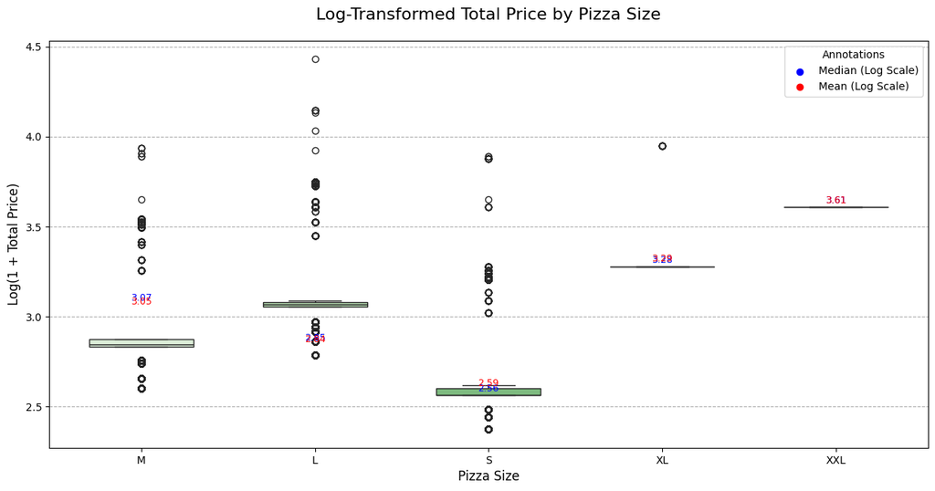

```python
# =======================================================================
# BOX PLOT OF LOG-TRANSFORMED total_price BY pizza_size
# CONFIRMATION: THIS VERSION KEEPS ALL VALUES AND ANNOTATIONS IN LOG SCALE
# =======================================================================

plt.figure(figsize=(15, 7))  # Adjust figure size for horizontal layout

# CREATE BOX PLOT USING LOG-TRANSFORMED DATA
ax = sns.boxplot(
    x="pizza_size",
    y="total_price",
    data=df_log_transformed,  # This df is already log-transformed
    palette="Greens",
    width=0.6
)

# CALCULATE STATISTICS ON THE LOG-TRANSFORMED SCALE
medians = df_log_transformed.groupby("pizza_size")["total_price"].median()
means = df_log_transformed.groupby("pizza_size")["total_price"].mean()

# ADD ANNOTATIONS FOR MEDIANS AND MEANS DIRECTLY IN LOG SCALE
# NO BACK-CONVERSION TO ORIGINAL SCALE IS PERFORMED
for i, median in enumerate(medians):
    ax.text(
        i, median + 0.02,
        f"{median:.2f}",   # Log scale median
        horizontalalignment="center",
        fontsize=9,
        color="blue"
    )

for i, mean in enumerate(means):
    ax.text(
        i, mean + 0.02,
        f"{mean:.2f}",     # Log scale mean
        horizontalalignment="center",
        fontsize=9,
        color="red"
    )

# ADD TITLE, LABELS, AND GRID
plt.title("Log-Transformed Total Price by Pizza Size", fontsize=16, pad=20)
plt.xlabel("Pizza Size", fontsize=12)
plt.ylabel("Log(1 + Total Price)", fontsize=12)  # The axis and annotations align with log scale
plt.xticks(rotation=0, fontsize=10)
plt.grid(axis='y', linestyle='--')

# ADD LEGEND FOR MEAN AND MEDIAN WITH CLEAR LABELING
plt.scatter([], [], color="blue", label="Median (Log Scale)")
plt.scatter([], [], color="red", label="Mean (Log Scale)")
plt.legend(loc="upper right", title="Annotations")

# DISPLAY THE PLOT
plt.show()
```

👆 OBSERVATION

- THE ORIGINAL PLOT (NO TRANSFORMATION) DISPLAYED A WIDE RANGE OF VALUES WITH EXTREMELY TALL Y-SCALE DUE TO HIGH OUTLIERS, MAKING THE BOXES APPEAR SQUASHED NEAR THE BOTTOM.
- APPLYING THE LOG TRANSFORMATION REDUCED THE IMPACT OF THESE EXTREME VALUES, BRINGING THE DATA CLOSER TOGETHER IN TERMS OF SCALE, AND CLARIFYING SOME RELATIONSHIPS BETWEEN PIZZA SIZES AND TOTAL PRICE.
- HOWEVER, EVEN AFTER THE LOG TRANSFORMATION, THE BOXES REMAIN RELATIVELY FLAT, INDICATING THAT THE MAJORITY OF ORDERS STILL CLUSTER TIGHTLY WITHIN A NARROW PRICE RANGE—EITHER IN ORIGINAL OR LOG SCALE.
- WHILE THIS MAY APPEAR TO BE A “WASTED EFFORT,” ATTEMPTING A LOG TRANSFORMATION WAS IMPORTANT TO CONFIRM THAT OUTLIERS WEREN’T THE PRIMARY CAUSE OF THE VISUAL COMPRESSION, BUT RATHER THE INHERENT DISTRIBUTION OF THE DATA ITSELF.

### **Multivariate Analysis**

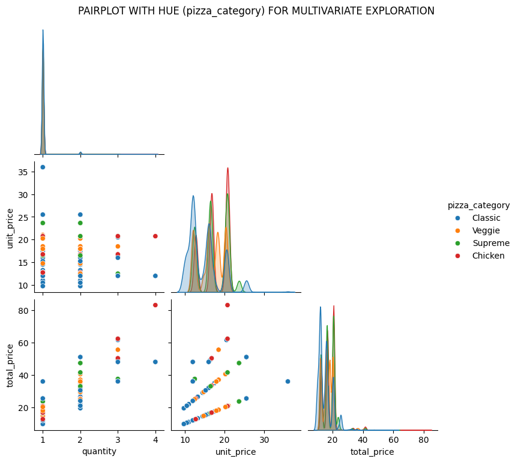

```python
# =====================================================================
# PAIRPLOT WITH HUE TO INTRODUCE A THIRD FEATURE (pizza_category)
# RELATIONSHIPS AMONG quantity, unit_price, total_price WITH CATEGORIES
# =====================================================================

selected_features = df[['quantity', 'unit_price', 'total_price', 'pizza_category']]
sns.pairplot(selected_features, hue='pizza_category', diag_kind='kde', corner=True)
plt.suptitle("PAIRPLOT WITH HUE (pizza_category) FOR MULTIVARIATE EXPLORATION", y=1.02)
plt.show()
```

👆 OBSERVATION

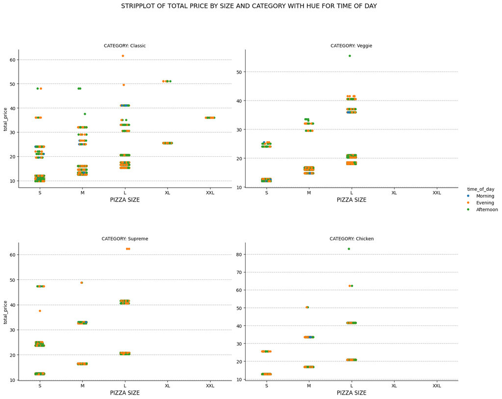

```python
# ====================================================================
# CATPLOT (STRIPPLOT) WITH HUE AND COL TO INTRODUCE MULTIPLE VARIABLES
# RELATIONSHIP BETWEEN total_price AND pizza_size,
# SEPARATED BY pizza_category, AND COLORED BY time_of_day
# ====================================================================

g = sns.catplot(
    data=df,
    x='pizza_size', y='total_price', hue='time_of_day',
    col='pizza_category', kind='strip',
    col_wrap=2,              # Arrange the subplots in a 2x2 grid
    height=6,                # Increase height for larger subplots
    aspect=1.2,              # Adjust aspect ratio for better readability
    jitter=True,
    sharex=False,            # Disable shared x-axis to ensure top subplots show labels
    sharey=False,
    order=['S', 'M', 'L', 'XL', 'XXL']  # Specify the logical order of pizza sizes
)

g.set_titles("CATEGORY: {col_name}")
g.fig.subplots_adjust(top=0.9, hspace=0.4)  # Additional vertical space
g.fig.suptitle("STRIPPLOT OF TOTAL PRICE BY SIZE AND CATEGORY WITH HUE FOR TIME OF DAY", y=1.02, fontsize=14)

# ADD GRID AND ENSURE LABELS ARE VISIBLE
for ax in g.axes.flat:
    ax.grid(axis='y', linestyle='--')
    ax.tick_params(axis='x', labelbottom=True)
    ax.set_xlabel("PIZZA SIZE", fontsize=12)

plt.show()
```

👆 OBSERVATION

- THE 2X2 GRID DISPLAYS TOTAL PRICE DISTRIBUTIONS ACROSS PIZZA SIZES FOR EACH CATEGORY.
- WHILE MOST POINTS CLUSTER IN THE LOWER PRICE RANGE REGARDLESS OF TIME OF DAY, CERTAIN SIZES WITHIN EACH CATEGORY OCCASIONALLY REACH HIGHER TOTAL PRICES, INDICATING A FEW COSTLIER ORDERS.
- HUE (TIME_OF_DAY) DOES NOT DRAMATICALLY SHIFT THE PRICE PATTERNS, SUGGESTING THAT ORDER TIMING MAY NOT BE A MAJOR INFLUENCE ON TOTAL PRICE DISTRIBUTION ACROSS SIZES AND CATEGORIES.
- MORNING TIME OF DAY CAN HARDLY BE VISUALIZED IN THESE PLOTS BECAUSE SO FEW ORDERS OCCUR IN THE MORNING HOURS.

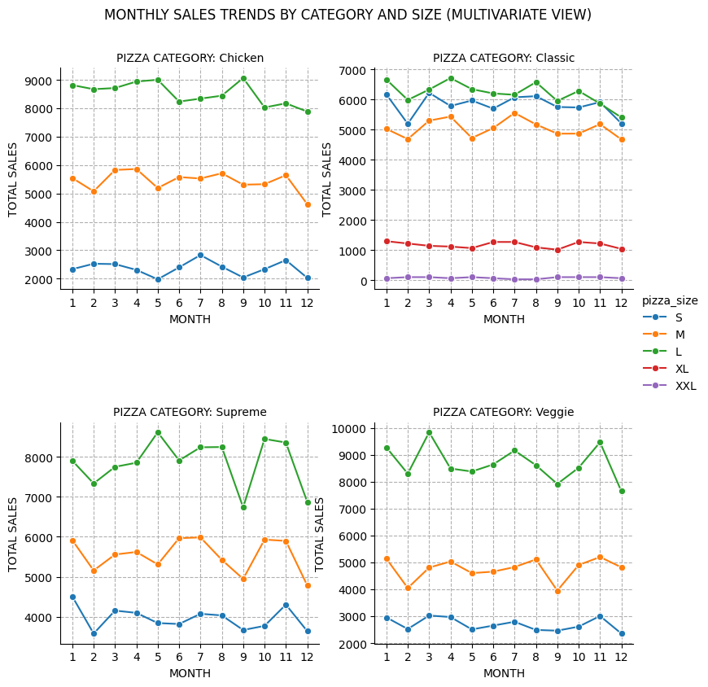

```python
# ===================================================
# FACETGRID LINE PLOT WITH MULTIPLE FEATURES
# ORDER_MONTH ON X-AXIS, total_price ON Y-AXIS,
# FACETED BY pizza_category AND COLORED BY pizza_size
# ===================================================
facet_data = df.groupby(['order_month', 'pizza_category', 'pizza_size'])['total_price'].sum().reset_index()

facet_data['order_month'] = facet_data['order_month'].astype(int)

g = sns.FacetGrid(
    facet_data,
    col='pizza_category', hue='pizza_size',
    col_wrap=2,
    height=4,
    sharey=False,
    sharex=False,
    hue_order=['S', 'M', 'L', 'XL', 'XXL']  # Specify the logical order for pizza_size in the legend
)
g.map_dataframe(sns.lineplot, x='order_month', y='total_price', marker='o')
g.add_legend()
g.set_titles(col_template="PIZZA CATEGORY: {col_name}")

for ax in g.axes.flat:
    ax.set_xlabel("MONTH", fontsize=10)
    ax.set_ylabel("TOTAL SALES", fontsize=10)
    ax.tick_params(axis='x', labelbottom=True)
    ax.set_xticks(range(1, 13))
    ax.grid(True, linestyle='--')

g.fig.subplots_adjust(hspace=0.6)
plt.suptitle("MONTHLY SALES TRENDS BY CATEGORY AND SIZE (MULTIVARIATE VIEW)", y=1.05)

plt.show()
```

👆 OBSERVATION

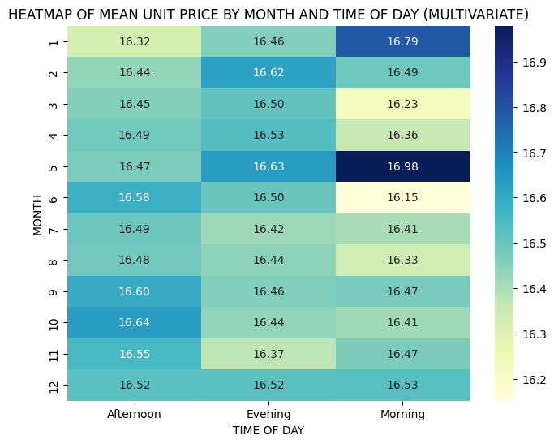

```python
# ====================================================================================================
# GROUPBY MULTIPLE FEATURES WITH AGGREGATION AND HEATMAP
# CREATE A PIVOT TABLE WITH order_month AS ROWS, time_of_day AS COLUMNS, AND MEAN unit_price AS VALUES
# THEN VISUALIZE WITH A HEATMAP
# ====================================================================================================

pivot_data = df.pivot_table(values='unit_price', index='order_month', columns='time_of_day', aggfunc='mean')
plt.figure(figsize=(8,6))
sns.heatmap(pivot_data, annot=True, cmap='YlGnBu', fmt='.2f')
plt.title("HEATMAP OF MEAN UNIT PRICE BY MONTH AND TIME OF DAY (MULTIVARIATE)")
plt.xlabel("TIME OF DAY")
plt.ylabel("MONTH")
plt.show()
```

👆 OBSERVATION

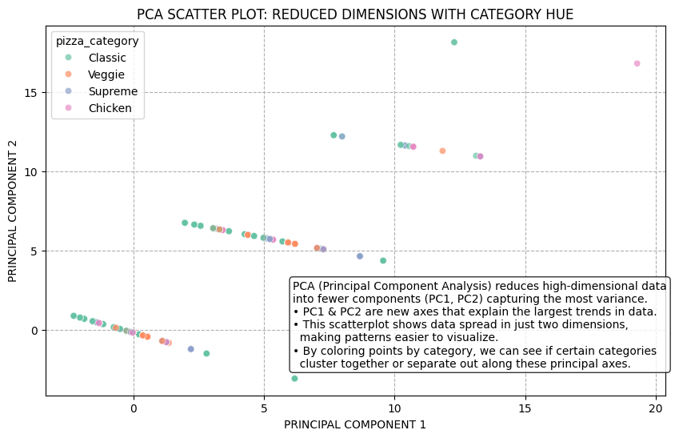

```python
# ==========================================================
# PRINCIPAL COMPONENT ANALYSIS (PCA) FOR DIMENSION REDUCTION
# REDUCE NUMERIC FEATURES TO TWO PRINCIPAL COMPONENTS
# PLOT THE FIRST TWO COMPONENTS WITH HUE AS pizza_category
# ==========================================================
from sklearn.decomposition import PCA
from sklearn.preprocessing import StandardScaler

numeric_features = df[['quantity', 'unit_price', 'total_price']].dropna()
scaled_data = StandardScaler().fit_transform(numeric_features)

pca = PCA(n_components=2)
pca_components = pca.fit_transform(scaled_data)

pca_df = pd.DataFrame(pca_components, columns=['PC1', 'PC2'])
pca_df['pizza_category'] = df.loc[numeric_features.index, 'pizza_category']

plt.figure(figsize=(10,6))
ax = sns.scatterplot(x='PC1', y='PC2', hue='pizza_category', data=pca_df, palette='Set2', alpha=0.7)

plt.title("PCA SCATTER PLOT: REDUCED DIMENSIONS WITH CATEGORY HUE")
plt.xlabel("PRINCIPAL COMPONENT 1")
plt.ylabel("PRINCIPAL COMPONENT 2")
plt.grid(True, linestyle='--')

# Add annotation explaining PCA in the lower right quadrant
annotation_text = (
    "PCA (Principal Component Analysis) reduces high-dimensional data\n"
    "into fewer components (PC1, PC2) capturing the most variance.\n"
    "• PC1 & PC2 are new axes that explain the largest trends in data.\n"
    "• This scatterplot shows data spread in just two dimensions,\n"
    "  making patterns easier to visualize.\n"
    "• By coloring points by category, we can see if certain categories\n"
    "  cluster together or separate out along these principal axes."
)

# Get current axis limits
x_min, x_max = ax.get_xlim()
y_min, y_max = ax.get_ylim()

# Place annotation in lower right quadrant
ax.text(
    x_max*0.3, y_min*0.6,   # Adjust these multipliers as needed to position text
    annotation_text,
    fontsize=10,
    color="black",
    va="bottom",
    ha="left",
    bbox=dict(boxstyle="round,pad=0.3", fc="white", ec="black", alpha=0.8)
)

plt.show()
```

👆 OBSERVATION

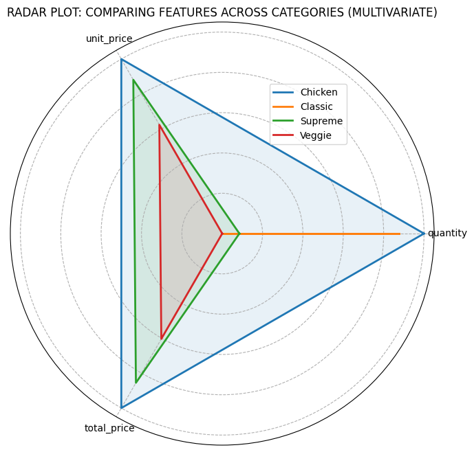

```python
# =====================================================================
# RADAR/POLAR PLOT (PARALLEL CATEGORIES) FOR MULTIVARIATE VIEW
# COMPARE MEAN FEATURES ACROSS MULTIPLE pizza_categories
# AGGREGATE MEAN OF quantity, unit_price, total_price FOR EACH CATEGORY
# THEN NORMALIZE AND PLOT ON A RADAR CHART
# =====================================================================


# ==== CALCULATE MEAN OF SELECTED NUMERIC FEATURES BY pizza_category
radar_data = df.groupby('pizza_category')[['quantity','unit_price','total_price']].mean()

# ==== NORMALIZE THE VALUES TO RANGE [0,1] FOR RADAR PLOT
radar_data_norm = (radar_data - radar_data.min()) / (radar_data.max() - radar_data.min())
categories = radar_data_norm.columns.tolist()
N = len(categories)

# ==== RADAR CHART SETUP
angles = [n / float(N) * 2 * np.pi for n in range(N)]
angles += angles[:1]

plt.figure(figsize=(10,8))
ax = plt.subplot(111, polar=True)

for cat in radar_data_norm.index:
    values = radar_data_norm.loc[cat].values.flatten().tolist()
    values += values[:1]
    ax.plot(angles, values, label=cat, linewidth=2)
    ax.fill(angles, values, alpha=0.1)

ax.set_xticks(angles[:-1])
ax.set_xticklabels(categories)
ax.set_yticklabels([])
ax.set_title("RADAR PLOT: COMPARING FEATURES ACROSS CATEGORIES (MULTIVARIATE)")
ax.grid(True, linestyle='--')
plt.legend(bbox_to_anchor=(0.6,0.7))
plt.show()
```

👆 OBSERVATION

- A RADAR PLOT IS A WAY TO VISUALIZE MULTIPLE VARIABLES FOR DIFFERENT CATEGORIES ON A SINGLE CHART. EACH AXIS REPRESENTS ONE FEATURE, AND ALL AXES RADIATE OUT FROM THE CENTER, ALLOWING DIRECT COMPARISONS OF CATEGORY "SHAPES" ACROSS MULTIPLE DIMENSIONS.
- NORMALIZING THE MEAN VALUES (SCALING THEM BETWEEN 0 AND 1) ENSURES THAT EACH FEATURE IS MEASURED ON THE SAME RELATIVE SCALE. THIS PREVENTS ANY SINGLE FEATURE WITH INHERENTLY LARGER VALUES FROM DOMINATING THE PLOT, MAKING IT EASIER TO SEE RELATIVE DIFFERENCES BETWEEN CATEGORIES.
- IN THIS RADAR PLOT, EACH PIZZA CATEGORY IS REPRESENTED BY A POLYGON FORMED BY CONNECTING POINTS ON THE AXES FOR quantity, unit_price, AND total_price. OBSERVING THE SHAPE AND SIZE OF EACH POLYGON HELPS IDENTIFY WHICH CATEGORIES TEND TO HAVE HIGHER OR LOWER NORMALIZED VALUES FOR THESE FEATURES.
- FOR EXAMPLE, IF THE POLYGON FOR THE "CHICKEN" CATEGORY EXTENDS FURTHER ALONG THE unit_price AXIS, IT INDICATES THAT CHICKEN PIZZAS HAVE RELATIVELY HIGHER UNIT PRICES COMPARED TO OTHER CATEGORIES. SIMILARLY, A CATEGORY'S POLYGON THAT IS SMALLER OR CLOSER TO THE CENTER ON ALL AXES SUGGESTS THAT IT GENERALLY RANKS LOWER ACROSS THESE NORMALIZED MEAN FEATURES.
- BY COMPARING THESE POLYGON SHAPES, VIEWERS CAN QUICKLY SEE PATTERNS: MAYBE ONE CATEGORY CONSISTENTLY SCORES HIGHER ON total_price, WHILE ANOTHER BALANCES OUT BETWEEN quantity AND unit_price. THE RADAR CHART’S ABILITY TO DISPLAY MULTIVARIATE DATA IN A SIMPLE, COMPARATIVE MANNER HELPS IDENTIFY WHICH CATEGORIES STAND OUT, WHICH ARE SIMILAR, AND WHERE POTENTIAL OPPORTUNITIES OR ANOMALIES LIE.

## **Data Preprocessing**

### Create Preprocessing Script

- Handle duplicates, missing values, date/time processing, and feature engineering for order_time, order_month, and time_of_day.

```python
# ====================================================
# CREATE A DIRECTORY TO STORE THE PREPROCESSING SCRIPT
# ====================================================
src_dir_job_scripts = "./project_scripts"
os.makedirs(src_dir_job_scripts, exist_ok=True)

# ===============================================================
# WRITE THE PRE_PROCESS.PY SCRIPT TO PROCESS THE PIZZA SALES DATA
# ===============================================================
preprocess_script_content = r'''
# =========================
# IMPORT REQUIRED LIBRARIES
# =========================
import argparse
import pandas as pd
from pathlib import Path
import numpy as np

# =============================================
# DEFINE A FUNCTION TO MAP HOURS TO TIME OF DAY
# =============================================
def map_time_of_day(x):
    # ==== IF HOUR BETWEEN 6 AND 12 => MORNING
    # ==== IF HOUR BETWEEN 12 AND 18 => AFTERNOON
    # ==== OTHERWISE => EVENING
    if 6 < x < 12:
        return "Morning"
    elif 12 < x < 18:
        return "Afternoon"
    else:
        return "Evening"

if __name__ == "__main__":
    # ==========================================
    # PARSE ARGUMENTS FOR INPUT AND OUTPUT PATHS
    # ==========================================
    parser = argparse.ArgumentParser()
    parser.add_argument("--data", type=str, help="PATH TO INPUT DATA")
    parser.add_argument("--output", type=str, help="PATH TO OUTPUT DATA")
    args = parser.parse_args()

    # ===========================================
    # READ THE INPUT DATA FROM THE SPECIFIED PATH
    # ===========================================
    df = pd.read_csv(args.data)

    # =================
    # REMOVE DUPLICATES
    # =================
    df = df.drop_duplicates()

    # ==========================================================
    # HANDLE MISSING VALUES BY DROPPING ROWS WITH MISSING VALUES
    # (ADJUST AS NEEDED FOR BUSINESS LOGIC)
    # ==========================================================
    df = df.dropna()

    # ==============================================================
    # CREATE A SINGLE DATETIME COLUMN FROM order_date AND order_time
    # 'format="mixed"' IS A PLACEHOLDER; USE APPROPRIATE PARSING LOGIC
    # ==============================================================
    df['order_time'] = pd.to_datetime(df['order_date'] + " " + df['order_time'], errors='coerce')

    # ========================================================
    # DROP THE order_date COLUMN AFTER MERGING INTO order_time
    # ========================================================
    df.drop(columns=['order_date'], inplace=True)

    # ==================================================
    # EXTRACT THE MONTH FROM order_time INTO order_month
    # ==================================================
    df['order_month'] = df['order_time'].dt.month

    # ====================================================
    # MAP THE HOUR OF order_time TO A TIME_OF_DAY CATEGORY
    # ====================================================
    df['time_of_day'] = df['order_time'].dt.hour.apply(map_time_of_day)

    # ===============================================================
    # //ONE-HOT ENCODE THE pizza_category COLUMN FOR BETTER MODEL INPUT
    # //AVOID ARTIFICIAL ORDERING ON CATEGORIES
    # //CREATE NEW BINARY INDICATOR COLUMNS
    # ===============================================================
    # Instead of overwriting df directly with get_dummies:
    temp_dummies = pd.get_dummies(df["pizza_category"], prefix="category", drop_first=False)
    df = pd.concat([df, temp_dummies], axis=1)
    # NOTE: do not drop df["pizza_category"] or daily_email_report.py will fail
    # df = pd.get_dummies(df, columns=['pizza_category'], prefix='category', drop_first=False)

    # ===================================================
    # DEFINE THE OUTPUT PATHS AND SAVE THE PROCESSED DATA
    # ===================================================
    output_data_store = args.output
    preprocessed_data_output_path = Path(output_data_store, "processed_data.csv")
    df.to_csv(preprocessed_data_output_path, index=False)
'''

with open(os.path.join(src_dir_job_scripts, "pre_process.py"), "w") as f:
    f.write(preprocess_script_content)
```

👆 OBSERVATION

- THIS CODE BLOCK CREATES A DIRECTORY AND WRITES A PREPROCESSING SCRIPT NAMED pre_process.py. THE SCRIPT EXECUTES DATA CLEANING, DERIVES NEW FEATURES LIKE order_month AND time_of_day, AND ENSURES THAT RAW PIZZA SALES DATA IS PREPARED FOR SUBSEQUENT STEPS IN THE MACHINE LEARNING PIPELINE.
- ALTHOUGH NO DIRECT OUTPUT APPEARS HERE, THE EXECUTION OF THESE STEPS FORMS A FOUNDATION FOR A REPRODUCIBLE, RELIABLE ANALYTICAL WORKFLOW, IMPROVING OVERALL DATA PROCESSING CONSISTENCY.
- THE ADDITION OF ONE-HOT ENCODING FOR THE pizza_category FEATURE CREATES MULTIPLE BINARY INDICATOR COLUMNS, ONE FOR EACH CATEGORY. THIS APPROACH ENSURES THAT NO ARTIFICIAL ORDERING IS IMPOSED ON CATEGORIES, FACILITATING MORE ACCURATE MODELING AND ANALYSIS BY TREATING EACH CATEGORY AS A DISTINCT, INDEPENDENT FEATURE.
- THE COMBINATION OF DATA CLEANING, FEATURE ENGINEERING, AND ONE-HOT ENCODING PRODUCES A HIGH-QUALITY, STRUCTURED DATASET SUITABLE FOR TRAINING MODELS AND CONDUCTING DETAILED ANALYSES WITHOUT INTRODUCING BIASES OR MISLEADING NUMERIC RELATIONSHIPS BETWEEN CATEGORIES.
- THE RESULT IS AN AUTOMATED, PORTABLE, AND SCALABLE PREPROCESSING STEP THAT CAN BE REUSED AS THE PIPELINE EVOLVES, ENSURING THAT FUTURE WORKLOADS RECEIVE THE SAME WELL-PREPARED DATA FOUNDATION.

### **Creating Preprocessing Job**

##### **Creating the Command Component for the Preprocessing Job**

##### **Define Preprocessing Step (Pipeline Step)**

```
- Define a preprocessing step using a command function:
    - Read a CSV input and process the data (with inputs and outputs specified as uri_folder).
    - Provide a clear name and display name.
    - Provide a description of its functionality.
    - Specify the source folder for the component and the command to execute a Python script for data preprocessing.
    - Use the designated docker conda environment for execution.
```

```python
# =====================================================
# IMPORT REQUIRED CLASSES FOR COMMAND COMPONENT CREATION
# =====================================================
# from azure.ai.ml import Input, Output, command
# from azure.ai.ml.entities import Environment

# ================================================================
# DEFINE THE DOCKER ENVIRONMENT
# ENSURE THE ENVIRONMENT DEFINITION MATCHES PREVIOUSLY CREATED ENV
# ================================================================
env_docker_conda = Environment(
    image="mcr.microsoft.com/azureml/openmpi4.1.0-ubuntu20.04",
    conda_file="./project_env/conda.yml",
    name="intelligent-reporting-azure",
    version="5",
    description="ENVIRONMENT WITH CONDA DEPENDENCIES FOR PIZZA SALES ANALYSIS"
)

# =======================================================
# DEFINE THE DATA PREPARATION STEP AS A COMMAND COMPONENT
# =======================================================
step_process_pre_process = command(
    name="data_prep_pizza",
    display_name="Data preparation for analysis",
    description="READ A .CSV INPUT, PROCESS AND TRANSFORM PIZZA SALES DATA",
    inputs={
        "data": Input(type="uri_folder")
    },
    outputs=dict(processed_data=Output(type="uri_folder", mode="rw_mount")),
    code='./project_scripts',
    command="python pre_process.py --data ${{inputs.data}} --output ${{outputs.processed_data}}",
    environment=env_docker_conda
)
```

👆 OBSERVATION

- A COMMAND COMPONENT DEFINES A SELF-CONTAINED STEP IN THE PIPELINE, EXECUTING A SPECIFIC SCRIPT WITH PRE-DEFINED INPUTS, OUTPUTS, AND COMPUTE RESOURCES. THIS COMPONENT ENFORCES CONSISTENCY AND REPRODUCIBILITY BY ENSURING THAT EACH STEP IN THE PIPELINE RUNS IN A STANDARDIZED MANNER.
- A DOCKER CONDA ENVIRONMENT COMBINES THE STABILITY OF A DOCKER IMAGE (AN OPERATING SYSTEM-LEVEL SNAPSHOT WITH ALL REQUIRED TOOLS) WITH THE FLEXIBILITY OF A CONDA ENVIRONMENT (A LIST OF DEPENDENCIES DEFINED IN A .YML FILE). THE .YML FILE, REFERRED TO AS A YAML FILE, SERVES AS A CONFIGURATION DOCUMENT THAT DECLARES EXACT VERSIONS OF PYTHON, LIBRARIES, AND DEPENDENCIES FOR THE ENVIRONMENT.
- THIS APPROACH ENSURES THAT THE SPECIFIC VERSIONS OF PACKAGES LISTED IN THE conda.yml FILE, ALONG WITH THE SELECTED DOCKER IMAGE, PRODUCE A PORTABLE AND CONSISTENT EXECUTION ENVIRONMENT. NO MATTER WHERE THE COMMAND COMPONENT RUNS—IN DIFFERENT REGIONS OR ON VARIOUS COMPUTE CLUSTERS—THE SAME DEPENDENCIES AND TOOLS WILL BE AVAILABLE, MINIMIZING ERRORS AND INCREASING RELIABILITY.
- ALTHOUGH NO IMMEDIATE VISUAL OUTPUT APPEARS FROM DEFINING THIS COMMAND COMPONENT AND ENVIRONMENT, THESE STEPS LAY THE FOUNDATION FOR A REPEATABLE, AUTOMATED ML PIPELINE. DEFINING THE ENVIRONMENT AND COMMAND COMPONENT IN THIS MANNER HELPS TO STREAMLINE SUBSEQUENT STEPS, SUCH AS DATA PREPROCESSING, MODEL TRAINING, AND DEPLOYMENT, WITHOUT INTRODUCING CONFLICTS OR INCONSISTENCIES IN DEPENDENCIES.

## **Reporting via Dashboard**

### **Streamlit Dashboard (app.py and requirements.txt)**

```
- Creating Files for the Dashboard
    - Creating Directory
    - Creating Dashboard Script
```

```python
# ======================================
# CREATE A DIRECTORY FOR STREAMLIT FILES
# ======================================
src_dir_hf_space = "./project_files"
os.makedirs(src_dir_hf_space, exist_ok=True)


# ======================================================
# WRITE THE STREAMLIT APP.PY FILE FOR DATA VISUALIZATION
# ======================================================
app_py_content = r'''
# =========================
# IMPORT REQUIRED LIBRARIES
# =========================
import streamlit as st
import seaborn as sns
import matplotlib.pyplot as plt
import pandas as pd


# ========================================
# DEFINE A FUNCTION TO LOAD PROCESSED DATA
# ========================================
def load_data():
    df = pd.read_csv("processed_data.csv")
    return df


# ================================
# DEFINE THE STREAMLIT APPLICATION
# ================================
def app():
    # ==== SET THE TITLE OF THE DASHBOARD
    st.title("Pizza Sales Data Analysis Dashboard")

    # ==== LOAD PROCESSED DATA
    df = load_data()
    df = pd.DataFrame(df)

    # ==== CALCULATE KEY METRICS
    total_orders = df['order_id'].nunique()
    total_revenue = df['total_price'].sum()
    most_popular_size = df['pizza_size'].value_counts().idxmax()
    most_frequent_category = df['pizza_category'].value_counts().idxmax()
    total_pizzas_sold = df['quantity'].sum()

    # ==== CREATE A SIDEBAR FOR KEY METRICS
    st.sidebar.header("Key Metrics")
    st.sidebar.metric("Total Orders", total_orders)
    st.sidebar.metric("Total Revenue", f"${total_revenue:,.2f}")
    st.sidebar.metric("Most Popular Size", most_popular_size)
    st.sidebar.metric("Most Popular Category", most_frequent_category)
    st.sidebar.metric("Total Pizzas Sold", total_pizzas_sold)

    # ==== DEFINE PLOTS TO DISPLAY
    plots = [
        {"title": "Top Selling Pizzas (by Quantity)", "x": "pizza_name", "y": "quantity", "top": 5},
        {"title": "Quantity of Pizzas Sold by Category and Time of the Day", "x": "time_of_day", "hue": "pizza_category"},
        {"title": "Quantity of Pizzas Sold by Size and Time of the Day", "x": "time_of_day", "hue": "pizza_size"},
        {"title": "Monthly Revenue Trends by Pizza Category", "x": "order_month", "y": "total_price", "hue": "pizza_category", "estimator": "sum", "marker": "o"}
    ]

    # ==== ITERATE OVER THE PLOTS AND RENDER THEM
    for plot in plots:
        st.header(plot["title"])
        fig, ax = plt.subplots()
        if "Top Selling Pizzas" in plot["title"]:
            data_aux = df.groupby(plot["x"])[plot["y"]].sum().reset_index().sort_values(by=plot["y"], ascending=False).head(plot["top"])
            ax.bar(data_aux[plot["x"]].values.tolist(), data_aux[plot["y"]].values.tolist())
        elif "Quantity of Pizzas" in plot["title"]:
            sns.countplot(data=df, x=plot["x"], hue=plot["hue"], ax=ax)
        elif "Monthly Revenue" in plot["title"]:
            sns.lineplot(data=df, x=plot["x"], y=plot["y"], hue=plot["hue"], estimator=plot["estimator"], errorbar=None, marker=plot["marker"], ax=ax)

        ax.set_xlabel(" ".join(plot["x"].split("_")).capitalize())
        if "y" in plot.keys():
            ax.set_ylabel(" ".join(plot["y"].split("_")).capitalize())
        else:
            ax.set_ylabel("Quantity")
        ax.legend(bbox_to_anchor=(1,1))
        st.pyplot(fig)


# =====================
# RUN THE STREAMLIT APP
# =====================
if __name__ == "__main__":
    app()
'''

with open(os.path.join(src_dir_hf_space, "app.py"), "w") as f:
    f.write(app_py_content)


# ============================================
# WRITE THE REQUIREMENTS.TXT FOR STREAMLIT APP
# ============================================
requirements_content = """
pandas==1.5.2
matplotlib==3.6.2
seaborn==0.12.1
scipy==1.10.0
numpy==1.23.5
"""

with open(os.path.join(src_dir_hf_space, "requirements.txt"), "w") as f:
    f.write(requirements_content)
```

👆 OBSERVATION

- THIS CODE BLOCK CREATES A DIRECTORY AND WRITES A STREAMLIT DASHBOARD SCRIPT (app.py) ALONG WITH A requirements.txt FILE FOR DATA VISUALIZATION OF PIZZA SALES DATA. THESE FILES SERVE AS A FRONT-END COMPONENT FOR ANALYTICAL INSIGHTS, ENABLING STAKEHOLDERS TO INTERACTIVELY EXPLORE METRICS, TRENDS, AND PATTERNS.
- NO IMMEDIATE OUTPUT APPEARS, BUT THESE ACTIONS CONFIGURE A CRITICAL PART OF THE MACHINE LEARNING PIPELINE, ENSURING THAT VISUALIZATION STEPS ARE VERSION-CONTROLLED AND REPRODUCIBLE. DEFINING THE DASHBOARD CODE AND DEPENDENCIES PRIOR TO RUNNING THE PIPELINE IMPROVES RELIABILITY AND MAINTENANCE.
- A COMMAND COMPONENT IS A PIPELINE ELEMENT THAT EXECUTES A SPECIFIC SCRIPT WITHIN A WELL-DEFINED ENVIRONMENT AND CONFIGURED DEPENDENCIES. COMMAND COMPONENTS ENFORCE CONSISTENCY, ENSURE THAT IDENTICAL OPERATIONS RUN ACROSS DIFFERENT EXECUTIONS, AND CONTRIBUTE TO MODULAR, SCALABLE PIPELINES.
- THE DOCKER CONDA ENVIRONMENT COMBINES A DOCKER IMAGE (PROVIDING A BASE OPERATING SYSTEM AND CORE TOOLS) WITH A CONDA ENVIRONMENT (DEFINED BY A .YML FILE) TO SPECIFY EXACT LIBRARY VERSIONS AND DEPENDENCIES. THE .YML (YAML) FILE HERE ACTS AS A BLUEPRINT FOR PACKAGE INSTALLATION, ENSURING THAT EVERY RUN OF THE PIPELINE USES THE SAME PYTHON PACKAGES AND LIBRARIES, THEREFORE PREVENTING CONFLICTS AND YIELDING PREDICTABLE RESULTS.
- THIS APPROACH ALLOWS THE VISUALIZATION COMPONENT TO OPERATE WITH FULL CONFIDENCE THAT REQUIRED TOOLS, SUCH AS seaborn AND pandas, ARE PRESENT IN THE PRECISE VERSIONS NEEDED, SUPPORTING CONSISTENT ANALYTICAL EXPERIENCES OVER TIME.

### Hugging Face Authentication and File Push Script

```
- Creating Script to Push Files to Hugging Face Space
```

```python
# ===============================================================
# WRITE THE SCRIPT TO AUTHENTICATE AND PUSH FILES TO HUGGING FACE
# ===============================================================
hugging_face_script_content = r'''
# =========================
# IMPORT REQUIRED LIBRARIES
# =========================
from huggingface_hub import login, HfApi
from datasets import Dataset
import argparse
import os
import pandas as pd

# ======================================
# CREATE OUTPUTS DIRECTORY IF NOT EXISTS
# ======================================
os.makedirs("./outputs", exist_ok=True)


# =========================================================
# DEFINE A FUNCTION TO SELECT THE FIRST FILE IN A DIRECTORY
# =========================================================
def select_first_file(path):
    files = os.listdir(path)
    return os.path.join(path, files[0])



if __name__ == '__main__':
    # ===============
    # PARSE ARGUMENTS
    # ===============
    parser = argparse.ArgumentParser()
    parser.add_argument("--processed_data_push", type=str, help="PATH TO PROCESSED DATA")
    parser.add_argument("--streamlit_files", type=str, help="PATH TO STREAMLIT FILES")
    args = parser.parse_args()

    # =====================================
    # DEFINE HUGGING FACE TOKEN AND REPO ID
    # =====================================
    hf_token = "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"
    hf_repo_id = "stevearchuleta/intelligent_reporting_via_Azure_ML_pipeline_pizza_sales_dashboard"



    # =====================
    # LOGIN TO HUGGING FACE
    # =====================
    login(token=hf_token)

    # =====================
    # INITIATE API INSTANCE
    # =====================
    api = HfApi()

    # ================================================
    # UPLOAD STREAMLIT FILES TO THE HUGGING FACE SPACE
    # ================================================
    if os.path.isdir(args.streamlit_files):
        api.upload_folder(
            folder_path=args.streamlit_files,
            repo_id=hf_repo_id,
            repo_type="space"
        )

    # ========================================================
    # UPLOAD THE PROCESSED DATA FILE TO THE HUGGING FACE SPACE
    # ========================================================
    if os.path.isdir(args.processed_data_push):
        file_to_upload = select_first_file(args.processed_data_push)
        api.upload_file(
            path_or_fileobj=file_to_upload,
            path_in_repo="processed_data.csv",
            repo_id=hf_repo_id,
            repo_type="space",
        )
'''

with open(os.path.join(src_dir_job_scripts, "hugging_face_auth_push_files.py"), "w") as f:
    f.write(hugging_face_script_content)
```

👆 OBSERVATION

- THE CODE BLOCK CREATES A PYTHON SCRIPT DESIGNED TO AUTHENTICATE WITH HUGGING FACE AND UPLOAD FILES DIRECTLY TO A HUGGING FACE SPACE. THIS APPROACH DEFINES A CLEAR, PROGRAMMATIC METHOD FOR SHARING PROCESSED DATA AND INTERFACE CODE (E.G., STREAMLIT FILES), ENSURING EASY ACCESS FOR COLLABORATORS AND STAKEHOLDERS.
- NO IMMEDIATE OUTPUT OCCURS, BUT DEFINING THIS SCRIPT IS ESSENTIAL FOR INTEGRATING DATA AND VISUALIZATIONS WITH EXTERNAL PLATFORMS LIKE HUGGING FACE. ESTABLISHING AUTHENTICATION AND UPLOAD STEPS WITHIN THE PIPELINE CREATES A PREDICTABLE AND REPRODUCIBLE PROCESS FOR DISTRIBUTING ANALYTICAL ARTIFACTS.
- LOGGING INTO HUGGING FACE VIA A TOKEN-BASED AUTHENTICATION AND USING THE HfApi CLASS TO UPLOAD FOLDERS OR SINGLE FILES ENSURES THAT PUBLIC OR PRIVATE DASHBOARDS, PROCESSED DATASETS, AND VISUALIZATION CODE CAN BE EASILY DEPLOYED AND MAINTAINED. THIS ENHANCES THE PIPELINE'S LONG-TERM UTILITY, PROMOTING COLLABORATION AND STREAMLINING THE TRANSFER OF ANALYTICAL OUTPUTS INTO ACCESSIBLE, SHAREABLE FORMATS.
- THE SCRIPT CLEARLY DEFINES INPUT ARGUMENTS FOR PROCESSED DATA AND STREAMLIT FILES. THIS DESIGN ENCOURAGES MODULARITY AND FLEXIBILITY, ALLOWING ADAPTATION TO FUTURE CHANGES IN DATA LOCATIONS OR AUTHENTICATION METHODS WITHOUT FUNDAMENTAL REWRITES OF THE UPLOAD LOGIC.

## **Creating the Command Component for the Dashboard Reporting Job**

### **Define Hugging Face Step (Pipeline Step)**

```
- Define a Hugging Face authentication step using a command function:
    - Authenticate to the Hugging Face hub.
    - Push specified files.
    - Provide a clear name and display name.
    - Provide a description of its functionality.
    - Include inputs for the path to the processed data and a folder containing Streamlit files.
    - Specify the source folder for the component and the command to execute a Python script for authentication and file upload.
    - Use the designated environment for execution.
```

```python
# =======================================================================
# DEFINE THE HUGGING FACE AUTH AND PUSH FILES STEP AS A COMMAND COMPONENT
# =======================================================================
step_hugging_auth = command(
    name="hugging_face_authentication_dashboard",
    display_name="hugging face authentication and push files",
    description="AUTHENTICATE WITH HUGGING FACE AND PUSH FILES TO THE HUB",
    inputs={
        "processed_data_push": Input(type="uri_file"),
        "streamlit_files": Input(type="uri_folder")
    },
    code='./project_scripts',
    command="python hugging_face_auth_push_files.py \
    --processed_data_push ${{inputs.processed_data_push}} \
    --streamlit_files ${{inputs.streamlit_files}}",
    environment=env_docker_conda
)
```

👆 OBSERVATION

- A COMMAND COMPONENT IS DEFINED TO AUTHENTICATE WITH HUGGING FACE AND PUSH FILES. THIS ACTION REPRESENTS AN INTEGRATED STEP IN THE MACHINE LEARNING PIPELINE, ENSURING THAT PROCESSED DATA AND STREAMLIT FILES CAN BE TRANSFERRED DIRECTLY TO AN EXTERNAL HUB.
- ALTHOUGH NO DIRECT VISUAL OUTPUT APPEARS, THIS CONFIGURATION LAYS THE GROUNDWORK FOR AUTOMATED DATA DISTRIBUTION. INCORPORATING THE HUGGING FACE COMMAND COMPONENT ALLOWS THE PIPELINE TO SEAMLESSLY PUBLISH ARTIFACTS, DASHBOARD FILES, AND OTHER ANALYTICAL RESULTS WITHOUT MANUAL INTERVENTION.
- INTEGRATING THE COMMAND COMPONENT WITH A PREDEFINED ENVIRONMENT NAMED "intelligent-reporting-azure" ENSURES THAT ALL REQUIRED DEPENDENCIES, AUTHENTICATION STEPS, AND LIBRARIES ARE CONSISTENTLY AVAILABLE. THIS APPROACH LEADS TO GREATER REPRODUCIBILITY, TRANSPARENCY, AND MAINTAINABILITY THROUGHOUT THE ENTIRE DATA SCIENCE WORKFLOW.
- AS THE PROJECT EVOLVES, THE ESTABLISHED INFRASTRUCTURE FOR EFFICIENT SHARING OF DATA AND VISUALIZATION ASSETS CAN BE EXPANDED OR ADJUSTED WITHOUT REWRITING CORE LOGIC, DEMONSTRATING A FLEXIBLE AND SCALABLE PIPELINE DESIGN.

## **Reporting via Email**

### **Creating Email Report Script**

```python
# ============================================================
# WRITE THE daily_email_report.py SCRIPT TO SEND EMAIL METRICS
# ============================================================
email_script_content = r'''
# =========================
# IMPORT REQUIRED LIBRARIES
# =========================
import argparse
import smtplib
from email.mime.multipart import MIMEMultipart
from email.mime.text import MIMEText
import pandas as pd
import os

# ======================================
# CREATE OUTPUTS DIRECTORY IF NOT EXISTS
# ======================================
os.makedirs("./outputs", exist_ok=True)


# =========================================================
# DEFINE A FUNCTION TO SELECT THE FIRST FILE IN A DIRECTORY
# =========================================================
def select_first_file(path):
    files = os.listdir(path)
    return os.path.join(path, files[0])


# =======================
# CONFIGURE EMAIL DETAILS
# =======================
email_config = {
    "sender_email": "usa2madeira@gmail.com",
    "receiver_emails": "stevearchuleta@me.com",
    "password": "kmes vcjr ubiq mfha",
    "smtp_server": "smtp.gmail.com",
    "smtp_port": 587
}


if __name__ == '__main__':
    # ===============
    # PARSE ARGUMENTS
    # ===============
    parser = argparse.ArgumentParser()
    parser.add_argument("--processed_data", type=str, help="PATH TO PROCESSED DATA")
    args = parser.parse_args()

    # =======================
    # READ THE PROCESSED DATA
    # =======================
    df = pd.read_csv(select_first_file(args.processed_data))

    # ======================================
    # CALCULATE KEY METRICS FOR EMAIL REPORT
    # ======================================
    total_orders = df['order_id'].nunique()
    total_revenue = df['total_price'].sum()
    most_popular_size = df['pizza_size'].value_counts().idxmax()
    most_frequent_category = df['pizza_category'].value_counts().idxmax()
    total_pizzas_sold = df['quantity'].sum()

    # ==========================
    # CREATE A REPORT DICTIONARY
    # ==========================
    report = {
        "Total Orders": total_orders,
        "Total Revenue": total_revenue,
        "Most Popular Pizza Size": most_popular_size,
        "Most Frequent Pizza Category": most_frequent_category,
        "Total Pizzas Sold": total_pizzas_sold
    }


    # =========================================
    # DEFINE A FUNCTION TO CREATE EMAIL CONTENT
    # =========================================
    def create_email_content(report):
        email_content = f"""
        <p>Dear Team,</p>
        <p>PLEASE FIND BELOW THE SUMMARY OF THE KEY METRICS FOR THE PIZZA SALES DATA:</p>
        <ul>
        <li><strong>Total Orders:</strong> {report['Total Orders']}</li>
        <li><strong>Total Revenue:</strong> ${report['Total Revenue']:.2f}</li>
        <li><strong>Most Popular Pizza Size:</strong> {report['Most Popular Pizza Size']}</li>
        <li><strong>Most Frequent Pizza Category:</strong> {report['Most Frequent Pizza Category']}</li>
        <li><strong>Total Pizzas Sold:</strong> {report['Total Pizzas Sold']}</li>
        </ul>
        <p>Regards,<br>Analytics Team</p>
        """
        return email_content

    # ==========================================
    # DEFINE A FUNCTION TO SEND THE EMAIL REPORT
    # ==========================================
    def send_email_report(email_config, report_metrics):
        email_content = create_email_content(report_metrics)
        server = smtplib.SMTP(email_config['smtp_server'], email_config['smtp_port'])
        server.starttls()
        server.login(email_config['sender_email'], email_config['password'])
        msg = MIMEMultipart()
        msg['From'] = email_config['sender_email']
        msg['To'] = email_config['receiver_emails']
        msg['Subject'] = 'Pizza Sales Analysis Report'
        msg.attach(MIMEText(email_content, 'html'))
        text = msg.as_string()
        server.sendmail(email_config['sender_email'], email_config['receiver_emails'], text)
        print(f"EMAIL REPORT SENT TO {email_config['receiver_emails']} SUCCESSFULLY!")
        server.quit()

    # ==========================================
    # CALL THE FUNCTION TO SEND THE EMAIL REPORT
    # ==========================================
    send_email_report(email_config, report)
'''

with open(os.path.join(src_dir_job_scripts, "daily_email_report.py"), "w") as f:
    f.write(email_script_content)
```

👆 OBSERVATION

- THIS CODE BLOCK CREATES A PYTHON SCRIPT THAT SENDS EMAIL REPORTS UPON COMPLETION OF DATA PROCESSING STEPS. THE SCRIPT DEFINES CREDENTIALS, AUTHENTICATES WITH GMAIL SERVERS, AND SENDS AUTOMATED REPORTS HIGHLIGHTING KEY METRICS FROM THE PROCESSED DATASET.
- THE FUNCTION send_email_report SERVES A CRITICAL PURPOSE. THE email_config DICTIONARY ONLY DEFINES CREDENTIALS AND SMTP SETTINGS. THE DEDICATED FUNCTION EXECUTES THE ACTUAL SEND OPERATION, BUILDING THE MIME MESSAGE AND TRANSFERRING THE REPORT THROUGH THE SMTP CONNECTION. WITHOUT THIS FUNCTION, MERELY DEFINING CONFIGURATIONS WOULD NOT INITIATE ANY EMAIL TRANSMISSION.
- THIS SETUP IS SUITABLE FOR INTEGRATION INTO A MACHINE LEARNING PIPELINE. THE DEFINED SCRIPT, ARGUMENT PARSING, AND REPORT GENERATION STEPS FACILITATE AUTOMATED NOTIFICATIONS ONCE DATA PROCESSING CONCLUDES. THESE ACTIONS ENHANCE PIPELINE OBSERVABILITY AND COMMUNICATION BY STREAMLINING THE DELIVERY OF INSIGHTS TO STAKEHOLDERS.

## **Creating the Command Component for the Email Reporting Job**

### **Define Email Reporting Step (Pipeline Step)**

```
- Define an email reporting step using a command function:
    - Send report emails based on processed pizza order data.
    - Provide a clear name and display name.
    - Provide a description of its functionality.
    - Include inputs for the processed data (as a URI folder).
    - Specify the source folder for the component and the command to execute a Python script that generates and sends the email report.
    - Use the designated environment for execution.
```

```python
# ======================================================
# DEFINE THE EMAIL REPORTING STEP AS A COMMAND COMPONENT
# ======================================================
step_process_report = command(
    name="email_report_pizza",
    display_name="report emails",
    description="READ THE PROCESSED DATA, COMPUTE METRICS, AND SEND EMAIL REPORT",
    inputs={
        "processed_data": Input(type="uri_folder"),
    },
    code='./project_scripts',
    command="python daily_email_report.py --processed_data ${{inputs.processed_data}}",
    environment=env_docker_conda
)
```

👆 OBSERVATION

- THIS CODE BLOCK DEFINES A COMMAND COMPONENT THAT HANDLES THE EMAIL REPORTING STEP OF THE PIPELINE. BY DECLARING THE NAME, DISPLAY NAME, DESCRIPTION, AND ENVIRONMENT, THE COMPONENT BECOMES A REUSABLE, SELF-CONTAINED MODULE WITH A CLEAR PURPOSE: TO READ PROCESSED DATA, COMPUTE KEY METRICS, AND SEND AUTOMATED EMAIL REPORTS.
- ALTHOUGH NO DIRECT VISUAL OUTPUT IS PRESENT, THIS CONFIGURATION ESTABLISHES A CRITICAL COMMUNICATION CHANNEL IN THE PIPELINE. ONCE THIS STEP RUNS, STAKEHOLDERS CAN RECEIVE TIMELY INSIGHTS VIA EMAIL WITHOUT MANUAL INTERVENTION, IMPROVING THE ACCESSIBILITY AND VALUE OF THE MACHINE LEARNING WORKFLOW.
- LINKING THE COMMAND COMPONENT TO THE 'intelligent-reporting-azure' ENVIRONMENT ENSURES THE NECESSARY LIBRARIES, AUTHENTICATION STEPS, AND EMAIL-RELATED DEPENDENCIES ARE AVAILABLE. THIS GUARANTEES THAT EMAIL SENDING OPERATIONS OCCUR RELIABLY AND CONSISTENTLY, FOSTERING CONFIDENCE IN THE PIPELINE'S ABILITY TO DELIVER NOTIFICATIONS AS EXPECTED.
- AS THE PIPELINE EVOLVES, THIS EMAIL REPORTING COMPONENT CAN BE MAINTAINED, UPDATED, OR REPLACED WITHOUT ALTERING THE REST OF THE CODEBASE. SUCH MODULARITY ENCOURAGES LONG-TERM SUSTAINABILITY, MAKING IT EASIER TO ADAPT THE PIPELINE TO NEW REQUIREMENTS, DATA SOURCES, OR REPORTING FORMATS IN THE FUTURE.

## **Building an Analytical Pipeline**

### **Assembling all Jobs into a Single Pipeline**

```
- Define an Azure ML pipeline for this Intelligent Reporting Project
    - #A. Data preparation step (processes the input CSV dataset, pizza_sales.csv).
    - #B. Hugging Face authentication and file push step (takes the processed data and specified Streamlit files as inputs).
    - #C. Email reporting step (generates and sends an email report based on the processed data).

- Name and Display Name to the pipeline.
- Description of pipeline's functionality.
- Specify input types (uri_file and uri_folder) and outputs.
- Designate environment and compute resources.
- Return relevant outputs (for downstream use and further analysis).
```

##### **Providing Paths for the Jobs**

```
- Instantiate the defined Azure ML pipeline (specify the input paths):
    - Provide the pizza sales data input as a URI file.
    - Provide the Hugging Face files input as a URI folder.
    - Reference inputs for pipeline execution.
```

##### **Executing the Pipeline**

```
- Create or update a job in Azure ML using the defined pipeline.
    - Associate the job with an experiment name ("Project 1 - Intelligent Reporting on Azure ML Pipeline.")
    - Utilize the previously instantiated pipeline for the run.
```

##### **Sample Output**

```
- Examples of logs or output artifacts (generated during the pipeline run).
- Summary metrics and/or completion status.
```

##### **Conclusions and Recommendations**

```
- Summarize the key insights and operational improvements realized from running the pipeline.
- Recommend future enhancements (such as adding additional transformations or integrating more data sources).
```

##### **Hugging Face Space Link and Dashboard Screenshot**

```
- Link to the Hugging Face space hosting the dashboard.
- Screenshot of the deployed Streamlit dashboard (demonstrating the visual insights).
```

##### **Email Report Screenshot**

```
- Screenshot of the email report (as received by the stakeholders).
```

```python
# ==============================================
# IMPORT NECESSARY MODULES FOR PIPELINE CREATION
# ==============================================
# from azure.ai.ml import dsl

# ============================
# DEFINE THE PIPELINE FUNCTION
# ============================
@dsl.pipeline(
    compute='cpu-cluster',
    description="PROJECT - INTELLIGENT REPORTING PIPELINE FOR PIZZA SALES"
)

def project_pipeline_(pipeline_job_data_input, hugging_face_folders):

    #A. ==== JOB 1: DATA PREPARATION JOB
    data_prep_job = step_process_pre_process(data=pipeline_job_data_input)

    #B. ==== JOB 2: HUGGING FACE AUTHENTICATION AND FILE PUSH JOB
    hugging_face_job = step_hugging_auth(
        processed_data_push=data_prep_job.outputs.processed_data,
        streamlit_files=hugging_face_folders
    )

    #C. ==== JOB 3: EMAIL REPORTING JOB
    # event_job is email_job... consider changing this variable name
    event_job = step_process_report(
        processed_data=data_prep_job.outputs.processed_data
    )

    # ==== RETURN PIPELINE OUTPUTS
    return {"pipeline_job_prep_data": data_prep_job.outputs.processed_data}

# ==============================================================
# DEFINE THE PATHS FOR INPUT REGISTERED DATA AND STREAMLIT FILES
# ==============================================================
datastore_data_asset = ml_client.data.get("pizza-analysis-data", version="1").path
streamlit_files_path = "./project_files"

# ==================================
# CREATE AN INSTANCE OF THE PIPELINE
# ==================================
pipeline = project_pipeline_(
    pipeline_job_data_input=Input(type="uri_file", path=datastore_data_asset),
    hugging_face_folders=Input(type="uri_folder", path=streamlit_files_path)
)

# =======================
# SUBMIT THE PIPELINE JOB
# =======================
pipeline_job = ml_client.jobs.create_or_update(
    pipeline,
    experiment_name="Project_01_Pizza_Sales_Intelligent_Reporting"
)
```

[output not shown]

## **FINAL COMMENTS | Sample Output**

#### 1. Conclusions and Recommendations

FINAL COMMENTS, INSIGHTS, RECOMMENDATIONS, AND CONCLUSIONS

**Problem Statement & Business Context Recap**  
A metropolitan-based pizza chain is grappling with operational hurdles: order fulfillment delays during peak hours leading to customer dissatisfaction, and difficulties with inventory management resulting in shortages or overstocking. By analyzing historical pizza sales data, the business aims to better predict demand, ensure efficient inventory turnover, and improve overall customer satisfaction. The ultimate objective is to reduce operational bottlenecks by automating and optimizing data-driven insights, from pre-processing steps through real-time reporting and stakeholder communication.

**Data Description**  
The dataset comprises approximately 48,620 records, each containing details about pizza orders, including pizza identifiers, order identifiers, dates, times, prices, sizes, categories, and ingredient lists. Through thorough exploratory analysis and feature engineering, the project prepared these raw data into a structured, ready-to-use dataset, ensuring robust time-based features and correct handling of outliers, data types, and categorical variables.

**Key Observations and Project Flow**

1. **Data Pre-Processing and Cleansing**
   - The data required careful cleaning to remove duplicates, handle missing values, and unify date and time columns into a single comprehensive order timestamp.
   - One-hot encoding was applied to the pizza_category feature to prevent imposing any artificial numeric ordering.
2. **Feature Engineering**
   - Creation of month-based and time-of-day features allowed the pipeline to support seasonal and hourly demand analyses.
   - Aggregations confirmed that most orders have a quantity of 1, but occasional larger orders do exist, highlighting potential spikes in resource use.
3. **Statistical Insights**
   - Unit prices clustered around a $16 average, while total prices occasionally spiked—important for identifying high-value or group orders.
   - Correlation between unit_price and total_price was relatively strong; quantity also influenced total_price, although fewer orders exceed a quantity of 2.
4. **Visual and Interactive Dashboard**
   - A Streamlit dashboard was created to allow interactive exploration of best-selling pizzas, time-of-day sales, and monthly trends.
   - Visuals, including boxplots, scatterplots, and heatmaps, exposed patterns such as the popularity of “Classic” category pizzas and the prevalence of size “L.”
5. **Hugging Face Integration**
   - A pipeline step authenticates with Hugging Face and uploads the processed data plus the dashboard script. This ensures reproducible sharing and an external space for collaboration.
6. **Automated Email Alerts**
   - A final pipeline step automatically emails key metrics (such as total revenue or most popular pizza sizes) to stakeholders, offering near-real-time insight into sales fluctuations and inventory considerations.

**Conclusions and Recommendations**

- **Demand Prediction and Inventory Strategy**
  - Because outliers largely represent multi-item or large-size orders, more sophisticated demand forecasting models could separate normal from peak-hour group orders. The business can then prepare for short bursts of heavy ordering by allocating staff and ingredients accordingly.
  - Daily or weekly patterns (notably more evening orders) indicate a need for upscaled evening staffing and reallocation of resources to reduce wait times.
- **Menu Refinement**
  - Data strongly suggests that certain pizza categories (like Classic and Supreme) and certain sizes (especially “L”) lead to higher or more stable revenue. Management can refine menus or promotions around these consistently popular options.
  - Low-frequency categories or ingredients might be re-evaluated: some rarely used ingredients could be replaced or made specialty items to reduce waste.
- **Enhancing Customer Satisfaction**
  - With the validated time-of-day feature, the business can run targeted promotions in low-demand times (morning, early afternoon) to smooth out labor and ingredient usage.
  - Quicker fulfillment at peak times (late afternoon and evening) can be achieved by pre-assembly stations or improved queue management.
- **Operational Next Steps**
  - Deploy a refined pipeline that integrates real-time ordering data and triggers rapid inventory updates and staff notifications.
  - Expand the pipeline to incorporate a more detailed segmentation: for instance, analyzing large events or group orders separately.
  - Continue collecting new data (like customer satisfaction ratings or promotional details) to strengthen predictive modeling and better align with consumer preferences.

By coupling data exploration, pipeline-driven automation, demand forecasting, and interactive reporting, the business can systematically address its operational challenges. The recommended approach is to maintain and enhance these pipeline steps—ensuring the dataset and models remain updated—so that every stage, from pre-processing to final email reporting, continues to empower data-driven decisions. Long term, these measures are poised to reduce wait times, optimize ingredients, and improve customer loyalty through a more streamlined, responsive pizza ordering experience.

#### 2. Hugging face space link and screenshot of dashboarding

https://huggingface.co/spaces/stevearchuleta/intelligent_reporting_via_Azure_ML_pipeline_pizza_sales_dashboard

[figure not shown]

#### 3. Email report screenshot

[figure not shown]

#### 4. Azure ML Project Pipeline

[figure not shown]